# Princípios de Econometria

### 11.0.2 Exemplo de Angrist e Pischke (2009): hospitais tornam as pessoas mais saudáveis?

Angrist e Pischke (2009, Cap. 2) introduzem o problema de seleção por meio de uma alegoria particularmente didática:

> **Os hospitais tornam as pessoas mais saudáveis?**

Os autores utilizam dados da *National Health Interview Survey* (NHIS) de 2005 e comparam a saúde autoavaliada de indivíduos hospitalizados e não hospitalizados. A variável de saúde varia de 1, correspondente a “ruim”, a 5, correspondente a “excelente”.

| Grupo | Número de indivíduos | Saúde média | Erro-padrão |
| --- | --- | --- | --- |
| Hospitalizado ($D_i=1$) | 7.774 | 3,21 | 0,014 |
| Não hospitalizado ($D_i=0$) | 90.049 | 3,93 | 0,003 |

A diferença observada é

$$3,21-3,93=-0,72.$$

Tomada literalmente, essa comparação sugeriria que as pessoas que foram hospitalizadas apresentam, em média, pior saúde do que aquelas que não foram hospitalizadas.

A interpretação causal ingênua seria:

> **Ir ao hospital reduz a saúde.**

O problema é evidente. As pessoas não são hospitalizadas aleatoriamente. Em geral, quem chega ao hospital já está em pior condição de saúde. Portanto, hospitalizados e não hospitalizados não constituem grupos diretamente comparáveis.

O ponto essencial do exemplo é que uma diferença estatisticamente grande e estimada com elevada precisão pode, ainda assim, ser uma medida inadequada do efeito causal. O problema não é necessariamente falta de precisão estatística. O problema é a **comparabilidade daquilo que está sendo comparado**.

**Exemplo e valores:** Angrist e Pischke (2009, Cap. 2, Seção 2.1).

## 11.1 O que gostaríamos realmente de comparar?

A diferença que observamos nos dados é

$$E[Y_i\mid D_i=1] - E[Y_i\mid D_i=0].$$

No exemplo do hospital, essa expressão compara:

1. a saúde média das pessoas que foram hospitalizadas;
2. a saúde média das pessoas que não foram hospitalizadas.

Mas essa não é exatamente a comparação causal que desejamos.

Para descobrir o efeito da hospitalização **sobre aqueles que foram hospitalizados**, gostaríamos de comparar:

$$E[Y_{1i}\mid D_i=1]$$

com

$$E[Y_{0i}\mid D_i=1].$$

O primeiro termo é observável. Ele representa a saúde média dos indivíduos hospitalizados sob hospitalização.

O segundo termo não é observável. Ele representa a saúde média que **essas mesmas pessoas** teriam apresentado se não tivessem sido hospitalizadas.

Em linguagem didática, gostaríamos de observar as mesmas pessoas em dois mundos alternativos:

- no primeiro mundo, elas são hospitalizadas;
- no segundo mundo, elas não são hospitalizadas.

A diferença entre esses dois mundos forneceria o efeito causal da hospitalização para os tratados.

**Fonte:** Angrist e Pischke (2009, Cap. 2, Seção 2.1).

### 11.1.1 ATT: efeito médio do tratamento sobre os tratados

O **Average Treatment Effect on the Treated (ATT)**, em português, **Efeito Médio do Tratamento sobre os Tratados**, é definido como

$$ATT
=
E[Y_{1i}-Y_{0i}\mid D_i=1].$$

Equivalentemente,

$$ATT
=
E[Y_{1i}\mid D_i=1]
-
E[Y_{0i}\mid D_i=1].$$

O ATT responde à seguinte pergunta:

> **Qual é, em média, o efeito causal do tratamento para os indivíduos que efetivamente receberam o tratamento?**

No exemplo hospitalar de Angrist e Pischke (2009), o ATT representa quanto a hospitalização altera, em média, o estado de saúde das pessoas que efetivamente foram hospitalizadas, relativamente ao estado de saúde contrafactual que essas mesmas pessoas teriam apresentado caso não fossem hospitalizadas.

O problema é que o termo

$$E[Y_{0i}\mid D_i=1]$$

não é observado. Para os indivíduos tratados, observamos $Y_{1i}$, mas não observamos $Y_{0i}$.

Esse é o ponto em que surge o problema de seleção.

**Fonte:** Angrist e Pischke (2009, Cap. 2, Seção 2.1).

### 11.1.2 A decomposição da diferença observada

Angrist e Pischke (2009, Cap. 2) mostram que a diferença observada entre tratados e não tratados pode ser decomposta em duas partes:

$$E[Y_i\mid D_i=1]-E[Y_i\mid D_i=0]$$

$$=
\underbrace{
E[Y_{1i}\mid D_i=1]
-
E[Y_{0i}\mid D_i=1]
}_{\text{ATT}}
+
\underbrace{
E[Y_{0i}\mid D_i=1]
-
E[Y_{0i}\mid D_i=0]
}_{\text{Viés de seleção}}.$$

A expressão pode ser resumida didaticamente como

$$\boxed{
\text{Diferença observada}
=
\text{efeito causal}
+
\text{viés de seleção}
}$$

Essa decomposição deve ser lida com cuidado.

#### 11.1.2.1 Primeiro componente: o efeito causal

O primeiro termo é

$$E[Y_{1i}\mid D_i=1]
-
E[Y_{0i}\mid D_i=1].$$

Ele compara os tratados com eles mesmos em dois estados possíveis. Esse é o ATT.

#### 11.1.2.2 Segundo componente: o viés de seleção

O segundo termo é

$$E[Y_{0i}\mid D_i=1]
-
E[Y_{0i}\mid D_i=0].$$

Ele pergunta:

> **Mesmo se ninguém recebesse o tratamento, os indivíduos que acabaram sendo tratados seriam, em média, diferentes daqueles que não foram tratados?**

Se a resposta for sim, existe seleção.

No exemplo hospitalar, é plausível que

$$E[Y_{0i}\mid D_i=1]
<
E[Y_{0i}\mid D_i=0].$$

Ou seja, mesmo em um mundo hipotético no qual ninguém fosse hospitalizado, as pessoas que efetivamente chegaram ao hospital provavelmente apresentariam pior saúde do que aquelas que não chegaram ao hospital.

Logo,

$$E[Y_{0i}\mid D_i=1]
-
E[Y_{0i}\mid D_i=0]
<0.$$

O viés de seleção é negativo.

Esse viés pode ser tão grande que uma hospitalização efetivamente benéfica apareça, na comparação observacional, associada a pior saúde.

> **Síntese didática:** no exemplo do hospital, não estamos simplesmente comparando “hospital versus ausência de hospital”. Estamos comparando pessoas que chegaram ao hospital com pessoas que não chegaram. A diferença entre esses grupos já existia antes do tratamento e contamina a comparação causal.

**Decomposição e exemplo:** Angrist e Pischke (2009, Cap. 2, Seção 2.1).

## 11.2 Atribuição aleatória: por que o sorteio resolve o problema de seleção?

A solução conceitual apresentada por Angrist e Pischke (2009) é a atribuição aleatória do tratamento.

Quando $D_i$ é determinado por sorteio, temos

$$D_i \perp (Y_{1i},Y_{0i}),$$

em que o símbolo $\perp$ indica **independência estatística**.

A expressão é lida como:

> **“O tratamento $D_i$ é independente dos resultados potenciais $Y_{1i}$ e $Y_{0i}$.”**

Isso significa que a probabilidade de receber o tratamento não depende de quais seriam os resultados da unidade com ou sem tratamento.

A randomização implica

$$E[Y_{0i}\mid D_i=1]
=
E[Y_{0i}\mid D_i=0]
=
E[Y_{0i}],$$

e

$$E[Y_{1i}\mid D_i=1]
=
E[Y_{1i}\mid D_i=0]
=
E[Y_{1i}].$$

Consequentemente,

$$E[Y_{0i}\mid D_i=1]
-
E[Y_{0i}\mid D_i=0]
=
0.$$

Portanto, o viés de seleção desaparece.

A diferença observada passa a ser

$$E[Y_i\mid D_i=1]-E[Y_i\mid D_i=0]
=
E[Y_{1i}-Y_{0i}].$$

Isto é, sob atribuição aleatória, a diferença média entre tratados e controles identifica o **Efeito Médio do Tratamento (ATE)**.

Podemos resumir:

$$\boxed{
\text{Sorteio}
\Rightarrow
D_i \perp (Y_{1i},Y_{0i})
\Rightarrow
\text{grupos comparáveis em média}
\Rightarrow
\text{viés de seleção}=0
}$$

É importante enfatizar que a randomização **não torna os indivíduos iguais**. Os indivíduos continuam diferentes em inúmeras dimensões. O que o sorteio faz é impedir que essas diferenças estejam sistematicamente associadas à atribuição do tratamento. Em média, os grupos tornam-se comparáveis.

**Fonte:** Angrist e Pischke (2009, Cap. 2, Seção 2.2).

### 11.2.1 Exemplos de Angrist e Pischke (2009): quando a evidência observacional engana

Angrist e Pischke (2009, Cap. 2) utilizam exemplos de diferentes áreas para mostrar que o problema de seleção não é apenas uma possibilidade teórica. Ele pode alterar substantivamente a conclusão de uma análise.

#### 11.2.1.1 Exemplo apresentado por Angrist e Pischke: terapia de reposição hormonal

Os autores contrastam evidências observacionais e experimentais sobre terapia de reposição hormonal.

Em dados não experimentais do *Nurses’ Health Study*, usuárias da terapia apresentavam melhores indicadores de saúde. Entretanto, resultados de um ensaio randomizado associado à *Women’s Health Initiative* apontaram poucos benefícios e revelaram efeitos adversos importantes que não eram aparentes nas comparações observacionais.

A interpretação destacada por Angrist e Pischke é a existência de seleção: mulheres que optavam pela terapia podiam ser diferentes, em dimensões relevantes para a saúde, daquelas que não a utilizavam.

O exemplo mostra que uma comparação observacional favorável ao tratamento não garante que o tratamento seja a causa do melhor resultado.

**Exemplo:** Angrist e Pischke (2009, Cap. 2, Seção 2.2).

#### 11.2.1.2 Exemplo apresentado por Angrist e Pischke: programas governamentais de treinamento

Outro exemplo utilizado pelos autores envolve programas subsidiados de treinamento profissional.

Comparações não experimentais entre participantes e não participantes frequentemente mostravam rendimentos menores entre os participantes. Uma interpretação apressada sugeriria que o treinamento reduz os rendimentos.

No entanto, esses programas são direcionados justamente a pessoas com baixo potencial de ganhos, como desempregados de longa duração e outros grupos desfavorecidos. Portanto, participantes e não participantes não são naturalmente comparáveis.

Angrist e Pischke relatam que avaliações randomizadas desses programas produziram, em geral, efeitos positivos, evidenciando o papel do viés de seleção nas comparações observacionais.

**Exemplo:** Angrist e Pischke (2009, Cap. 2, Seção 2.2).

### 11.2.2 Exemplo de Angrist e Pischke (2009): o experimento Tennessee STAR

Um dos principais estudos discutidos no Capítulo 2 é o **Tennessee STAR**, um experimento randomizado concebido para estimar o efeito do tamanho das turmas sobre o desempenho escolar.

A pergunta causal é direta:

> **Turmas menores melhoram o aprendizado dos alunos?**

Em dados observacionais, a resposta é difícil porque alunos com maiores dificuldades podem ser deliberadamente colocados em turmas menores. Nesse caso, uma associação entre turmas menores e pior desempenho pode resultar do processo de alocação dos alunos, e não de um efeito prejudicial das turmas pequenas.

O STAR foi concebido para romper essa seleção.

Segundo a descrição de Angrist e Pischke (2009), o experimento custou aproximadamente US$ 12 milhões, acompanhou cerca de 11.600 crianças e começou com uma coorte do *kindergarten* em 1985-1986, seguindo-a até a terceira série.

Os alunos foram atribuídos a três configurações:

1. turmas pequenas, com 13 a 17 alunos;
2. turmas regulares, com 22 a 25 alunos e auxiliar em tempo parcial;
3. turmas regulares, com auxiliar em tempo integral.

A lógica do desenho é a mesma da estrutura formal apresentada anteriormente: a atribuição aleatória busca tornar os grupos comparáveis, de modo que diferenças posteriores de desempenho possam ser atribuídas ao tratamento.

**Exemplo e desenho experimental:** Angrist e Pischke (2009, Cap. 2, Seção 2.2).

## 11.3 Testes de equilíbrio: a randomização parece ter funcionado?

Uma etapa natural na análise de um experimento consiste em comparar características determinadas antes do tratamento.

Angrist e Pischke (2009, Tabela 2.2.1) apresentam características dos grupos no experimento STAR.

| Variável | Turma pequena | Turma regular | Regular/Auxiliar | Valor-$p$ |
| --- | --- | --- | --- | --- |
| Almoço gratuito | 0,47 | 0,48 | 0,50 | 0,09 |
| Branco/Asiático | 0,68 | 0,67 | 0,66 | 0,26 |
| Idade em 1985 | 5,44 | 5,43 | 5,42 | 0,32 |
| Taxa de atrito | 0,49 | 0,52 | 0,53 | 0,02 |

Para características como raça e idade, as diferenças não são estatisticamente significativas aos níveis usuais, o que é consistente com o equilíbrio produzido pela randomização.

É importante formular essa interpretação corretamente. Um valor-$p$ elevado não prova que os grupos sejam literalmente idênticos. Ele indica que, para aquela covariável e naquela amostra, não se detecta evidência estatística de diferença entre os grupos.

O atrito merece atenção especial. A Tabela 2.2.1 registra diferença estatisticamente significativa nessa dimensão. Além disso, Angrist e Pischke observam que o STAR apresentou problemas práticos de implementação, incluindo saída de alunos que repetiam ou pulavam séries, entrada posterior de novos alunos e algum grau de troca de turmas após o *kindergarten*.

Essas limitações mostram que experimentos randomizados são uma referência extremamente poderosa, mas não estão livres de problemas de execução.

**Exemplo e tabela:** Angrist e Pischke (2009, Cap. 2, Tabela 2.2.1 e discussão subsequente).

### 11.3.1 Resultado central do STAR

A evidência apresentada por Angrist e Pischke (2009) indica que alunos alocados em turmas pequenas obtiveram resultados aproximadamente cinco pontos mais altos na distribuição percentílica dos testes, equivalentes a cerca de $0,2$ desvio-padrão.

O ponto substantivo é que o resultado experimental difere da interpretação que poderia emergir de comparações observacionais simples.

Se alunos com dificuldades forem sistematicamente colocados em turmas menores, uma comparação não experimental pode fazer turmas pequenas parecerem menos eficazes. A randomização quebra esse mecanismo de seleção e fornece uma comparação mais próxima do ideal *ceteris paribus*.

**Exemplo e resultado:** Angrist e Pischke (2009, Cap. 2, Tabela 2.2.2 e discussão do experimento STAR).

### 11.3.2 Exemplo de Angrist e Pischke (2009): da randomização real ao quase-experimento

Experimentos reais são frequentemente caros, inviáveis ou inexistentes. Angrist e Pischke (2009) argumentam que, nesses casos, o experimento randomizado continua funcionando como **benchmark conceitual**.

O objetivo passa a ser encontrar uma fonte de variação que imite, tanto quanto possível, uma atribuição aleatória.

#### 11.3.2.1 Regra de Maimônides e tamanho das turmas em Israel

Como exemplo, os autores discutem o estudo de Angrist e Lavy (1999).

Em Israel, uma regra administrativa estabelecia um limite de 40 alunos por turma. Assim, uma coorte com 40 estudantes podia formar uma única turma de 40, enquanto uma coorte com 41 estudantes precisava ser dividida, produzindo duas turmas muito menores.

A ideia é que alunos pertencentes a coortes de tamanho 40 e 41 são, plausivelmente, semelhantes em outras dimensões. A mudança abrupta no tamanho da turma induzida pela regra pode ser tratada como uma fonte de variação “como se fosse aleatória”.

Angrist e Pischke mostram esse caso como exemplo de como dados não experimentais podem ser analisados com **espírito experimental**.

A comparação ingênua entre turmas grandes e pequenas sugeria desempenho pior em turmas menores. O desenho quase-experimental apontou, em contraste, uma relação favorável entre turmas menores e desempenho.

Mais uma vez, a mensagem é a mesma:

$$\text{associação observada}
\neq
\text{efeito causal}$$

quando existe seleção.

**Exemplo:** Angrist e Pischke (2009, Cap. 2, final da Seção 2.2).

### 11.3.3 Regressão curta: o experimento em uma equação

Angrist e Pischke (2009, Seção 2.3) mostram como a lógica experimental pode ser expressa em uma regressão.

Suponha, por simplicidade, que o efeito do tratamento seja constante:

$$Y_{1i}-Y_{0i}=\rho.$$

Nesse caso,

$$Y_i=\alpha+\rho D_i+\eta_i,$$

em que

$$\alpha=E[Y_{0i}]$$

e

$$\eta_i=Y_{0i}-E[Y_{0i}].$$

O parâmetro $\rho$ representa o efeito do tratamento sob a hipótese de efeito constante.

Tomando médias condicionais,

$$E[Y_i\mid D_i=1]
=
\alpha+\rho+E[\eta_i\mid D_i=1],$$

e

$$E[Y_i\mid D_i=0]
=
\alpha+E[\eta_i\mid D_i=0].$$

Subtraindo,

$$E[Y_i\mid D_i=1]-E[Y_i\mid D_i=0]$$

$$=
\rho
+
\left\{
E[\eta_i\mid D_i=1]
-
E[\eta_i\mid D_i=0]
\right\}.$$

O termo

$$E[\eta_i\mid D_i=1]
-
E[\eta_i\mid D_i=0]$$

é novamente o viés de seleção.

Portanto, o problema de seleção pode ser traduzido para a linguagem da regressão: ele surge quando o componente não observado do resultado está sistematicamente associado ao tratamento.

No caso de um regressor binário $D_i$, a diferença entre as médias condicionais de $\eta_i$ está diretamente relacionada à covariância entre $D_i$ e $\eta_i$. Sob randomização,

$$D_i \perp \eta_i,$$

de modo que

$$E[\eta_i\mid D_i=1]
=
E[\eta_i\mid D_i=0].$$

Assim, a regressão curta recupera o efeito causal sem o componente de seleção.

**Fonte:** Angrist e Pischke (2009, Cap. 2, Seção 2.3, equação 2.3.1).

## 11.4 Regressão longa: por que incluir covariáveis em dados experimentais?

A regressão pode ser ampliada para

$$Y_i
=
\alpha
+
\rho D_i
+
X_i'\gamma
+
\eta_i,$$

em que $X_i$ representa um vetor de covariáveis.

Angrist e Pischke (2009, Seção 2.3) destacam dois papéis principais para os controles em dados experimentais.

#### 11.4.0.1 Respeitar o desenho de randomização

No STAR, a atribuição a turmas de diferentes tamanhos foi aleatória **dentro das escolas**, e não entre todas as escolas de maneira irrestrita.

Isso significa que alunos de escolas diferentes poderiam enfrentar probabilidades ligeiramente distintas de serem alocados a uma turma pequena. Além disso, escolas poderiam apresentar diferenças sistemáticas de desempenho.

Por essa razão, algumas especificações incluem **efeitos fixos de escola**, isto é, um intercepto específico para cada escola. O objetivo é alinhar a análise estatística ao desenho efetivo da randomização e realizar as comparações relevantes dentro dos blocos em que o sorteio ocorreu.

No caso do STAR, Angrist e Pischke observam que esse ajuste produz pouca alteração nos resultados, mas esse é um fato empírico que precisa ser verificado.

#### 11.4.0.2 Aumentar a precisão

Outras covariáveis do STAR incluem características dos alunos, como raça, idade e participação no programa de almoço gratuito.

Como essas características estão aproximadamente equilibradas entre os grupos, sua inclusão não deveria alterar sistematicamente a estimativa de $\rho$.

Assim, espera-se que as estimativas obtidas na regressão curta,

$$Y_i=\alpha+\rho D_i+\eta_i,$$

e na regressão longa,

$$Y_i=\alpha+\rho D_i+X_i'\gamma+\eta_i,$$

sejam próximas.

Entretanto, se $X_i$ explica parte da variação de $Y_i$, sua inclusão pode reduzir a variância residual e produzir uma estimativa mais precisa de $\rho$, isto é, com menor erro-padrão.

> **Síntese:** em um experimento randomizado, controles não são normalmente necessários para “consertar” seleção entre tratamento e controle. Eles podem ser importantes para respeitar uma randomização condicional e para melhorar a precisão da estimação.

**Fonte:** Angrist e Pischke (2009, Cap. 2, Seção 2.3, equações 2.3.1 e 2.3.2 e discussão do STAR).

### 11.4.1 O experimento ideal como referência para a econometria aplicada

O ponto mais geral do Capítulo 2 de Angrist e Pischke (2009) é que um ensaio randomizado fornece um **benchmark** para a interpretação causal.

Na maioria das aplicações econômicas, não temos um experimento verdadeiro. Os dados são produzidos por escolhas de indivíduos, decisões de empresas, políticas públicas, instituições e outras forças econômicas.

Ainda assim, a pergunta experimental permanece útil:

1. **Qual seria o tratamento?**
2. **Qual seria o grupo de controle ideal?**
3. **Qual é o contrafactual que gostaríamos de observar?**
4. **Por que tratados e não tratados podem diferir mesmo sem tratamento?**
5. **Qual é a provável fonte de viés de seleção?**
6. **Existe alguma variação nos dados que se aproxime de uma atribuição aleatória?**

Essa sequência orienta a escolha de estratégias empíricas.

O foco passa a ser menos a aplicação automática de uma técnica e mais a construção de uma comparação capaz de sustentar uma interpretação causal.

**Fonte:** Angrist e Pischke (2009, Cap. 2, especialmente final da Seção 2.2).

## 11.5 Síntese

O problema central da inferência causal pode ser expresso de forma compacta:

$$\boxed{
\text{Diferença observada}
=
\text{efeito causal}
+
\text{viés de seleção}
}$$

O efeito médio do tratamento sobre os tratados é

$$ATT
=
E[Y_{1i}-Y_{0i}\mid D_i=1].$$

O termo contrafactual

$$E[Y_{0i}\mid D_i=1]$$

não é diretamente observado. Quando usamos os não tratados como substitutos desse contrafactual, a comparação somente possui interpretação causal se os dois grupos forem adequadamente comparáveis.

A atribuição aleatória produz essa comparabilidade porque

$$D_i\perp(Y_{1i},Y_{0i}).$$

Consequentemente,

$$E[Y_{0i}\mid D_i=1]
=
E[Y_{0i}\mid D_i=0],$$

e o viés de seleção desaparece.

Em termos didáticos:

$$\boxed{
\text{Randomização}
\Rightarrow
\text{tratamento independente dos resultados potenciais}
\Rightarrow
\text{grupos comparáveis em média}
\Rightarrow
\text{viés de seleção}=0
}$$

Essa é a razão pela qual Angrist e Pischke (2009) tratam o experimento randomizado como referência para a pesquisa empírica.

O princípio orientador pode ser resumido em uma pergunta:

$$\boxed{
\text{Qual comparação permite interpretar a diferença observada como efeito causal?}
}$$

É a partir dessa pergunta que se desenvolvem as estratégias de identificação utilizadas quando a randomização verdadeira não está disponível.

## 11.6 Prática com dados simulados

Os três exercícios apresentados neste material são **hipotéticos e foram elaborados especificamente para fins didáticos**. Eles não reproduzem exemplos empíricos da obra de Angrist e Pischke.

O objetivo é mostrar, em uma sequência única, três situações:

1. o modelo de resultados potenciais com seleção não aleatória;
2. a eliminação do viés de seleção por atribuição aleatória;
3. a análise de um experimento randomizado com regressão e um vetor de covariáveis relevantes.

### 11.6.1 Exercício 1. Resultados potenciais e viés de seleção

#### 11.6.1.1 Contexto

Uma universidade deseja avaliar o efeito de um **programa intensivo de tutoria** sobre a nota final dos estudantes.

Defina:

$$D_i=
\begin{cases}
1, & \text{se o estudante participa da tutoria},\\
0, & \text{caso contrário}.
\end{cases}$$

Para cada estudante existem dois resultados potenciais:

$$Y_{1i}=\text{nota final se receber tutoria}$$

e

$$Y_{0i}=\text{nota final se não receber tutoria}.$$

Suponha, para simplificar, que a tutoria aumente a nota de todos os alunos em exatamente 5 pontos:

$$Y_{1i}-Y_{0i}=5.$$

Portanto,

$$ATE=ATT=5.$$

Na simulação, como somos os responsáveis pela construção artificial da população, podemos observar $Y_{0i}$ e $Y_{1i}$. Em dados reais, isso é impossível.

#### 11.6.1.2 Simulação em R

```r
# ==========================================================
# EXERCÍCIO 1
# Resultados potenciais e viés de seleção
# ==========================================================

set.seed(237)

N <- 800

# Características observadas dos estudantes
nota_previa <- rnorm(N, mean = 60, sd = 10)
renda <- pmax(rnorm(N, mean = 3, sd = 1), 0.5)
mulher <- rbinom(N, size = 1, prob = 0.5)

# Componente não observado
u <- rnorm(N, mean = 0, sd = 5)

# Resultado potencial SEM tratamento
Y0 <- 20 +
      0.60 * nota_previa +
      1.50 * renda +
      2.00 * mulher +
      u

# Efeito causal da tutoria
tau <- 5

# Resultado potencial COM tratamento
Y1 <- Y0 + tau

# Verdadeiro efeito médio do tratamento
ATE <- mean(Y1 - Y0)

ATE
```

```
[1] 5
```

Por construção,

$$ATE=5.$$

Agora introduzimos **seleção não aleatória**. Suponha que a universidade ofereça prioritariamente tutoria aos estudantes que apresentam notas iniciais mais baixas.

```r
# Participação NÃO aleatória no programa
D <- as.integer(
  nota_previa + rnorm(N, 0, 4) < 58
)

table(D)
```

```
D
  0   1
440 360
```

O resultado observado é definido por

$$Y_i=D_iY_{1i}+(1-D_i)Y_{0i}.$$

Em R:

```r
Y <- D * Y1 + (1 - D) * Y0
```

Agora podemos comparar tratados e não tratados:

```r
media_tratados <- mean(Y[D == 1])
media_controles <- mean(Y[D == 0])

diferenca_observada <- media_tratados - media_controles

diferenca_observada
```

```
[1] -4.361543
```

#### 11.6.1.3 O que devemos notar:

Essa diferença **não é necessariamente igual a 5**, embora saibamos que o verdadeiro efeito causal seja exatamente 5.

A razão é que os estudantes que receberam tutoria foram selecionados justamente por apresentarem pior desempenho inicial.

Podemos verificar diretamente a decomposição:

```r
# ATT verdadeiro
ATT <- mean(Y1[D == 1] - Y0[D == 1])

# Viés de seleção
vies_selecao <- mean(Y0[D == 1]) -
                mean(Y0[D == 0])

# Diferença observada
diferenca_observada <- mean(Y[D == 1]) -
                       mean(Y[D == 0])

c(
  ATT = ATT,
  vies_selecao = vies_selecao,
  diferenca_observada = diferenca_observada,
  ATT_mais_vies = ATT + vies_selecao
)
```

```
                ATT        vies_selecao diferenca_observada       ATT_mais_vies
           5.000000           -9.361543           -4.361543           -4.361543
```

O exercício demonstra empiricamente que:

$$\boxed{
E[Y_i\mid D_i=1]-E[Y_i\mid D_i=0]
=
ATT+
\text{Viés de Seleção}
}$$

Como os estudantes tratados já apresentavam condições menos favoráveis,

$$E[Y_{0i}\mid D_i=1]
<
E[Y_{0i}\mid D_i=0],$$

e, portanto,

$$\text{Viés de Seleção}<0.$$

A diferença observada pode, assim, **subestimar fortemente o verdadeiro benefício da tutoria**.

#### 11.6.1.4 Pergunta para os alunos

Se sabemos que o programa aumenta a nota em 5 pontos para todos os alunos, por que a simples comparação entre participantes e não participantes não recupera esse efeito?

A resposta deve enfatizar que

$$\text{tratados}\neq\text{controles}$$

mesmo antes do tratamento.

### 11.6.2 Exercício 2. O mesmo problema com atribuição aleatória

Agora suponha que a universidade disponha de vagas limitadas e decida distribuir a tutoria por **sorteio**.

A intervenção continua exatamente a mesma. Os resultados potenciais também continuam os mesmos:

$$Y_{1i}=Y_{0i}+5.$$

A única mudança é a forma de determinar $D_i$.

#### 11.6.2.1 Randomização em R

```r
# ==========================================================
# EXERCÍCIO 2
# Experimento randomizado
# ==========================================================

set.seed(237)

# Metade recebe tratamento e metade é controle
D_random <- sample(
  c(rep(1, N / 2),
    rep(0, N / 2))
)

table(D_random)
```

```
D_random
  0   1
400 400
```

O resultado observado passa a ser:

```r
Y_random <- D_random * Y1 +
            (1 - D_random) * Y0
```

Calculamos a diferença de médias:

```r
media_tratamento <- mean(Y_random[D_random == 1])
media_controle <- mean(Y_random[D_random == 0])

efeito_estimado <- media_tratamento -
                   media_controle

efeito_estimado
```

```
[1] 4.835056
```

Compare com:

```r
ATE
```

```
[1] 5
```

O resultado estimado não precisa ser exatamente igual a 5 em uma determinada amostra.

Isso é importante.

A randomização não implica

$$\widehat{ATE}=ATE$$

em toda realização do experimento.

Ela implica que, em expectativa,

$$E[\widehat{ATE}]=ATE.$$

#### 11.6.2.2 Verificando o equilíbrio

A randomização também deve produzir grupos semelhantes, em média, quanto às características anteriores ao tratamento.

```r
aggregate(
  nota_previa,
  by = list(tratamento = D_random),
  FUN = mean
)
```

```
  tratamento        x
1          0 60.42322
2          1 59.84035
```

```r
aggregate(
  renda,
  by = list(tratamento = D_random),
  FUN = mean
)
```

```
  tratamento        x
1          0 3.009975
2          1 3.012300
```

```r
aggregate(
  mulher,
  by = list(tratamento = D_random),
  FUN = mean
)
```

```
  tratamento      x
1          0 0.4975
2          1 0.5025
```

Agora compare com a seleção do Exercício 1:

```r
aggregate(
  nota_previa,
  by = list(tratamento = D),
  FUN = mean
)
```

```
  tratamento        x
1          0 67.06582
2          1 51.65686
```

A diferença conceitual é fundamental.

No Exercício 1,

$$D_i$$

é determinado, em parte, pelo desempenho do estudante.

No Exercício 2,

$$D_i$$

é determinado por sorteio.

Logo,

$$D_i\perp(Y_{1i},Y_{0i}).$$

Em consequência,

$$E[Y_{0i}\mid D_i=1]
=
E[Y_{0i}\mid D_i=0],$$

em expectativa.

Portanto,

$$\text{Viés de seleção}=0.$$

#### 11.6.2.3 A propriedade por repetição do experimento

Uma demonstração ainda mais didática consiste em repetir o mesmo experimento muitas vezes:

```r
set.seed(237)

B <- 2000

estimativas <- replicate(B, {

  D_b <- sample(
    c(rep(1, N / 2),
      rep(0, N / 2))
  )

  Y_b <- D_b * Y1 +
         (1 - D_b) * Y0

  mean(Y_b[D_b == 1]) -
    mean(Y_b[D_b == 0])
})

mean(estimativas)
```

```
[1] 5.012632
```

```r
sd(estimativas)
```

```
[1] 0.5862119
```

Podemos visualizar a distribuição amostral:

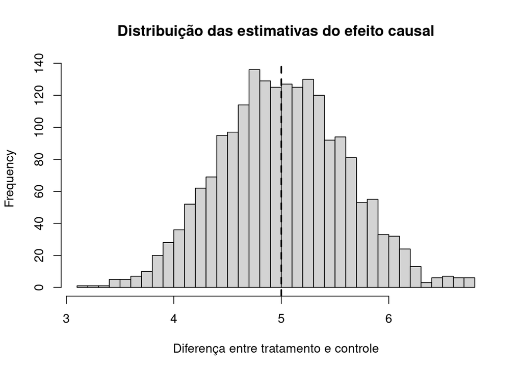

```r
hist(
  estimativas,
  breaks = 30,
  main = "Distribuição das estimativas do efeito causal",
  xlab = "Diferença entre tratamento e controle"
)

abline(
  v = ATE,
  lwd = 2,
  lty = 2
)
```

A distribuição das estimativas ficará centrada aproximadamente em

$$ATE=5.$$

Essa é uma demonstração computacional da ideia:

$$\boxed{
\text{Randomização}
\Rightarrow
D_i\perp(Y_{1i},Y_{0i})
\Rightarrow
\text{viés de seleção}=0
}$$

### 11.6.3 Exercício 3. Experimento randomizado com vetor de covariáveis

Agora analisaremos o mesmo experimento por regressão.

Começamos com a chamada **regressão curta**:

$$Y_i=\alpha+\rho D_i+\eta_i.$$

Como $D_i$ é binário, o coeficiente de $D_i$ corresponde à diferença de médias entre tratamento e controle.

#### 11.6.3.1 Regressão curta

```r
modelo_curto <- lm(
  Y_random ~ D_random
)

summary(modelo_curto)
```

```
Call:
lm(formula = Y_random ~ D_random)

Residuals:
     Min       1Q   Median       3Q      Max
-22.0611  -5.5990  -0.6245   5.4676  26.6547

Coefficients:
            Estimate Std. Error t value Pr(>|t|)
(Intercept)  61.7614     0.4163 148.353  < 2e-16 ***
D_random      4.8351     0.5888   8.212 8.71e-16 ***
---
Signif. codes:  0 '***' 0.001 '**' 0.01 '*' 0.05 '.' 0.1 ' ' 1

Residual standard error: 8.326 on 798 degrees of freedom
Multiple R-squared:  0.07793,   Adjusted R-squared:  0.07677
F-statistic: 67.44 on 1 and 798 DF,  p-value: 8.71e-16
```

O coeficiente associado a `D_random` estima

$$\rho.$$

Compare diretamente:

```r
coef(modelo_curto)["D_random"]
```

```
D_random
4.835056
```

```r
mean(Y_random[D_random == 1]) -
  mean(Y_random[D_random == 0])
```

```
[1] 4.835056
```

Os dois valores serão iguais, salvo diferenças puramente numéricas de arredondamento.

Isso ocorre porque, com uma variável explicativa binária, a regressão

$$Y_i=\alpha+\rho D_i+\eta_i$$

produz

$$\hat{\rho}
=
\bar Y_1-\bar Y_0.$$

#### 11.6.3.2 Incluindo um vetor de covariáveis

Suponha agora que o pesquisador observe:

$$X_i=
\begin{bmatrix}
\text{nota prévia}_i\\
\text{renda}_i\\
\text{mulher}_i
\end{bmatrix}.$$

Estimamos a regressão longa:

$$Y_i
=
\alpha
+
\rho D_i
+
X_i'\gamma
+
\eta_i.$$

Em R:

```r
modelo_longo <- lm(
  Y_random ~
    D_random +
    nota_previa +
    renda +
    mulher
)

summary(modelo_longo)
```

```
Call:
lm(formula = Y_random ~ D_random + nota_previa + renda + mulher)

Residuals:
     Min       1Q   Median       3Q      Max
-13.2394  -3.8213  -0.2924   3.8236  16.0237

Coefficients:
            Estimate Std. Error t value Pr(>|t|)
(Intercept) 20.19648    1.24683  16.198  < 2e-16 ***
D_random     5.17625    0.37014  13.985  < 2e-16 ***
nota_previa  0.60474    0.01805  33.496  < 2e-16 ***
renda        1.40422    0.19132   7.339 5.30e-13 ***
mulher       1.60424    0.37000   4.336 1.64e-05 ***
---
Signif. codes:  0 '***' 0.001 '**' 0.01 '*' 0.05 '.' 0.1 ' ' 1

Residual standard error: 5.232 on 795 degrees of freedom
Multiple R-squared:  0.6372,    Adjusted R-squared:  0.6354
F-statistic: 349.1 on 4 and 795 DF,  p-value: < 2.2e-16
```

Agora compare apenas o coeficiente do tratamento e seu erro-padrão:

```r
resultado_curto <- coef(summary(modelo_curto))[
  "D_random",
  c("Estimate", "Std. Error")
]

resultado_longo <- coef(summary(modelo_longo))[
  "D_random",
  c("Estimate", "Std. Error")
]

rbind(
  Regressao_curta = resultado_curto,
  Regressao_longa = resultado_longo
)
```

```
                Estimate Std. Error
Regressao_curta 4.835056  0.5887584
Regressao_longa 5.176255  0.3701366
```

#### 11.6.3.3 Qual é a expectativa?

Como o tratamento foi randomizado,

$$D_i\perp X_i$$

em expectativa.

Portanto, não precisamos controlar por $X_i$ para solucionar um problema de seleção causado por essas covariáveis.

Assim, esperamos:

$$\hat{\rho}_{curta}
\approx
\hat{\rho}_{longa}.$$

Os valores não precisam ser exatamente iguais em uma amostra finita.

Entretanto, `nota_previa`, `renda` e `mulher` ajudam a explicar o resultado $Y_i$. Sua inclusão pode reduzir a parte inexplicada da variação de $Y_i$.

Podemos verificar:

```r
summary(modelo_curto)$sigma
```

```
[1] 8.326301
```

```r
summary(modelo_longo)$sigma
```

```
[1] 5.232324
```

A expectativa é:

$$\widehat{\sigma}_{longa}
<
\widehat{\sigma}_{curta}.$$

Consequentemente, o erro-padrão de $\hat{\rho}$ também pode diminuir.

A comparação relevante é:

```r
coef(summary(modelo_curto))["D_random", "Std. Error"]
```

```
[1] 0.5887584
```

```r
coef(summary(modelo_longo))["D_random", "Std. Error"]
```

```
[1] 0.3701366
```

#### 11.6.3.4 A interpretação econométrica

Esse exercício permite fazer uma distinção didática importante.

No **Exercício 1**, as covariáveis são relevantes porque ajudam a explicar por que tratados e não tratados são diferentes. Existe seleção.

No **Exercício 2**, a randomização quebra essa relação:

$$D_i\perp(Y_{1i},Y_{0i}).$$

No **Exercício 3**, acrescentamos $X_i$ à regressão não porque a randomização tenha falhado, mas porque variáveis preditivas do resultado podem aumentar a **precisão** da estimativa.

Assim:

$$\boxed{
\begin{array}{c}
\text{Randomização}\\
\Downarrow\\
\text{identificação causal}
\end{array}
}$$

enquanto

$$\boxed{
\begin{array}{c}
\text{Covariáveis preditivas}\\
\Downarrow\\
\text{potencial ganho de precisão}
\end{array}
}$$

Essa distinção é central.

### 11.6.4 Exercício 4. Revisão

Após executar todos os códigos, complete e discuta a seguinte tabela:

| Situação | Tratamento aleatório? | Viés de seleção esperado? | $\hat{\rho}$ identifica efeito causal? | Papel de $X$ |
| --- | --- | --- | --- | --- |
| Seleção para tutoria |  |  |  |  |
| Experimento randomizado |  |  |  |  |
| Experimento + controles |  |  |  |  |

Síntese:

$$\boxed{
\text{Regressão não cria causalidade. O desenho de identificação é que permite a interpretação causal.}
}$$

No experimento randomizado, a regressão é essencialmente uma forma conveniente de estimar e apresentar a comparação produzida pelo desenho experimental.

# 12 Fundamentos da Regressão[^19]

A regressão é uma das principais ferramentas da econometria aplicada. Entretanto, é fundamental separar duas questões.

Primeiro, **o que uma regressão descreve estatisticamente?** Segundo, **quando essa descrição pode receber interpretação causal?**

Essas questões não são equivalentes. Uma regressão pode descrever muito bem uma relação entre variáveis sem que essa relação represente causa e efeito. O ponto de partida para compreender essa distinção é a **função de esperança condicional** (*conditional expectation function*, CEF).

## 12.1 Natureza da regressão?

### 12.1.1 A função de esperança condicional

Considere uma variável de resultado $Y_i$ e um vetor de características observáveis $X_i$. A função

$$E[Y_i\mid X_i]$$

mostra o valor médio de $Y_i$ entre unidades que apresentam determinado valor de $X_i$.

Por exemplo, se $Y_i$ representa o logaritmo dos salários e $X_i$ representa anos de escolaridade,

$$E[Y_i\mid X_i=x]$$

é o salário médio, em logaritmo, das pessoas com $x$ anos de escolaridade.

Essa relação pode ser muito informativa mesmo antes de qualquer interpretação causal. No exemplo utilizado pelos autores, os salários médios tendem a crescer com a escolaridade. Isso significa que escolaridade **prediz** salários. Por si só, contudo, essa relação não demonstra que mais escolaridade **cause** maiores salários.

Uma propriedade fundamental é a **lei das esperanças iteradas**:

$$E[Y_i]
=
E\left\{E[Y_i\mid X_i]\right\}.
\tag{3.1.1}$$

A média populacional de $Y_i$ pode ser obtida calculando primeiro as médias condicionais a $X_i$ e depois fazendo a média dessas médias segundo a distribuição de $X_i$.

Outra propriedade central é a decomposição

$$Y_i
=
E[Y_i\mid X_i]+\varepsilon_i,$$

com

$$E[\varepsilon_i\mid X_i]=0.$$

Assim, $Y_i$ pode ser dividido em duas partes:

1. uma parte sistematicamente relacionada a $X_i$, dada pela CEF;
2. uma parte residual, $\varepsilon_i$, cuja média condicional a $X_i$ é zero.

A CEF também é o melhor preditor de $Y_i$, dado $X_i$, quando o critério é minimizar o erro quadrático médio.

### 12.1.2 Regressão como aproximação da CEF

Considere a regressão populacional

$$Y_i=X_i'\beta+e_i.$$

O vetor $\beta$ é definido como aquele que minimiza o erro quadrático esperado:

$$\beta
=
\arg\min_b
E\left[(Y_i-X_i'b)^2\right].
\tag{3.1.2}$$

Da condição de primeira ordem,

$$E[X_i(Y_i-X_i'\beta)]=0,$$

segue que

$$\beta
=
E[X_iX_i']^{-1}E[X_iY_i].$$

Portanto,

$$E[X_ie_i]=0.$$

Esse resultado deve ser interpretado com cuidado. O fato de o erro de regressão ser não correlacionado com os regressores decorre da própria definição da regressão populacional. **Não é, por si só, uma hipótese causal.**

### 12.1.3 Regressão simples

Na regressão de $Y_i$ sobre uma constante e uma variável $X_i$,

$$Y_i=\alpha+\beta X_i+e_i,$$

o coeficiente angular populacional é

$$\beta
=
\frac{\operatorname{Cov}(Y_i,X_i)}
{\operatorname{Var}(X_i)}.$$

Portanto, $\beta$ mede a associação linear entre $X_i$ e $Y_i$.

### 12.1.4 Regressão múltipla

Em uma regressão com várias covariáveis, o coeficiente de uma variável pode ser entendido usando a **anatomia da regressão**. Seja $\widetilde X_{ki}$ o resíduo obtido ao regredir $X_{ki}$ sobre todas as outras covariáveis. Então

$$\beta_k
=
\frac{\operatorname{Cov}(Y_i,\widetilde X_{ki})}
{\operatorname{Var}(\widetilde X_{ki})}.
\tag{3.1.3}$$

Logo, o coeficiente de $X_{ki}$ mede sua relação com $Y_i$ usando apenas a variação em $X_{ki}$ que permanece depois de retirar sua associação linear com os demais regressores.

### 12.1.5 Por que a regressão é útil mesmo quando a CEF não é linear?

Se

$$E[Y_i\mid X_i]=X_i'\beta,$$

a regressão coincide exatamente com a CEF.

Mas a linearidade não é necessária para que a regressão seja útil. Mesmo quando

$$E[Y_i\mid X_i]$$

é não linear, $X_i'\beta$ fornece sua **melhor aproximação linear no sentido de erro quadrático médio mínimo**:

$$\beta
=
\arg\min_b
E
\left[
\left(
E[Y_i\mid X_i]-X_i'b
\right)^2
\right].
\tag{3.1.4}$$

Esse é um dos argumentos centrais do capítulo: **a regressão não precisa ser literalmente o verdadeiro modelo econômico para ser uma ferramenta estatística útil**. Ela resume a CEF por meio de sua melhor aproximação linear.

### 12.1.6 Da população para a amostra: OLS

Na prática, não conhecemos $\beta$. Dispomos de uma amostra e estimamos seu análogo amostral por **mínimos quadrados ordinários** (*ordinary least squares*, OLS):

$$\widehat{\beta}
=
\left(
\sum_{i=1}^{N}X_iX_i'
\right)^{-1}
\left(
\sum_{i=1}^{N}X_iY_i
\right).$$

Sob condições adequadas e em grandes amostras,

$$\widehat{\beta}
\xrightarrow{p}
\beta.$$

Ou seja, OLS é consistente para o coeficiente de regressão populacional.

Mas isso ainda não responde à pergunta causal. A inferência estatística nos permite avaliar a precisão com que estimamos $\beta$. Ela não determina o que $\beta$ significa.

### 12.1.7 Erros-padrão robustos

Os autores enfatizam o uso de erros-padrão consistentes sob heterocedasticidade. A variância assintótica de $\widehat{\beta}$ tem a forma

$$E[X_iX_i']^{-1}
E[X_iX_i'e_i^2]
E[X_iX_i']^{-1}.
\tag{3.1.7}$$

Sob homocedasticidade,

$$E[e_i^2\mid X_i]=\sigma^2,$$

essa expressão se simplifica para

$$\sigma^2E[X_iX_i']^{-1}.
\tag{3.1.8}$$

O ponto prático é importante. A heterocedasticidade é perfeitamente compatível com a interpretação da regressão como aproximação da CEF. Por isso, os autores dão destaque aos erros-padrão robustos.

### 12.1.8 Modelos saturados

Um modelo é **saturado** quando possui parâmetros suficientes para representar todas as médias condicionais associadas aos valores possíveis das covariáveis discretas.

Se $S_i$ assume os valores $0,1,\ldots,\tau$, podemos escrever

$$Y_i
=
\alpha+
\beta_1D_{1i}
+\beta_2D_{2i}
+\cdots+
\beta_\tau D_{\tau i}
+\varepsilon_i,$$

em que

$$D_{ji}=1[S_i=j].$$

Nesse caso,

$$\beta_j
=
E[Y_i\mid S_i=j]
-
E[Y_i\mid S_i=0].$$

Um modelo saturado reproduz exatamente a CEF para covariáveis discretas.

Com duas variáveis binárias, por exemplo, a saturação exige efeitos principais e a interação:

$$E[Y_i\mid X_{1i},X_{2i}]
=
\alpha
+\beta_1X_{1i}
+\gamma X_{2i}
+\delta(X_{1i}X_{2i}).$$

A interação permite que o efeito associado a uma variável seja diferente dependendo do valor da outra.

## 12.2 Regressão versus causalidade

Até aqui, a regressão foi tratada como ferramenta de descrição estatística. Para interpretá-la causalmente, precisamos de hipóteses adicionais.

Considere novamente o exemplo da escolaridade.

Para simplificar, suponha inicialmente que $C_i$ indique se o indivíduo concluiu a faculdade:

$$C_i=
\begin{cases}
1,&\text{se concluiu faculdade},\\
0,&\text{caso contrário}.
\end{cases}$$

Sejam $Y_{1i}$ e $Y_{0i}$ os rendimentos potenciais com e sem faculdade. O resultado observado é

$$Y_i
=
Y_{0i}+(Y_{1i}-Y_{0i})C_i.$$

A simples diferença de rendimentos é

$$E[Y_i\mid C_i=1]
-
E[Y_i\mid C_i=0].$$

Ela pode ser decomposta em

$$\underbrace{
E[Y_{1i}-Y_{0i}\mid C_i=1]
}_{\text{efeito médio do tratamento sobre os tratados}}
+
\underbrace{
E[Y_{0i}\mid C_i=1]
-
E[Y_{0i}\mid C_i=0]
}_{\text{viés de seleção}}.
\tag{3.2.1}$$

Pessoas que frequentam a faculdade podem ser diferentes das demais mesmo na ausência da faculdade. Por isso, a diferença observada de salários pode misturar **efeito causal** e **seleção**.

### 12.2.1 A hipótese de independência condicional

A principal hipótese utilizada para dar interpretação causal à regressão observacional é a **hipótese de independência condicional** (*conditional independence assumption*, CIA), também denominada seleção sobre observáveis:

$$\{Y_{0i},Y_{1i}\}
\perp C_i
\mid X_i.
\tag{3.2.2}$$

Ela afirma que, depois de condicionarmos adequadamente em $X_i$, o tratamento é independente dos resultados potenciais.

Sob essa hipótese,

$$E[Y_i\mid X_i,C_i=1]
-
E[Y_i\mid X_i,C_i=0]
=
E[Y_{1i}-Y_{0i}\mid X_i].$$

Portanto, dentro de grupos comparáveis em $X_i$, a diferença observada pode ser interpretada causalmente.

> **Ponto central:** regressão não cria causalidade. A interpretação causal depende de uma hipótese sobre o processo que determina o tratamento e sobre quais variáveis devem ser mantidas constantes.

#### 12.2.1.1 Escolaridade com vários valores

Se $S_i$ representa anos de escolaridade, seja

$$f_i(s)$$

o rendimento potencial do indivíduo $i$ caso tenha $s$ anos de escolaridade.

A CIA torna-se

$$Y_{si}\perp S_i\mid X_i
\qquad
\text{para todo }s.$$

Nesse caso, comparações de médias condicionais entre níveis de escolaridade podem receber interpretação causal:

$$E[Y_i\mid X_i,S_i=s]
-
E[Y_i\mid X_i,S_i=s-1]
=
E[f_i(s)-f_i(s-1)\mid X_i].$$

### 12.2.2 Regressão causal linear

Considere, para simplificar, um modelo causal linear com efeito constante:

$$f_i(s)=\alpha+\rho s+\eta_i.
\tag{3.2.7}$$

Para a escolaridade observada $S_i$,

$$Y_i=\alpha+\rho S_i+\eta_i.
\tag{3.2.8}$$

Agora suponha que

$$\eta_i=X_i'\gamma+v_i.$$

Então,

$$Y_i
=
\alpha
+
\rho S_i
+
X_i'\gamma
+
v_i.
\tag{3.2.9}$$

Se a CIA for válida dado $X_i$, $\rho$ pode ser interpretado como o efeito causal da escolaridade no modelo.

Portanto, as variáveis de controle não são incluídas simplesmente porque estão disponíveis. Elas são incluídas porque devem tornar plausível a comparação de indivíduos com diferentes valores de $S_i$.

### 12.2.3 Viés de variável omitida

A fórmula do **viés de variável omitida** (*omitted variables bias*, OVB) é uma das ferramentas mais importantes para compreender regressões múltiplas.

Considere a regressão longa

$$Y_i
=
\alpha+\rho S_i+A_i'\gamma+e_i,
\tag{3.2.10}$$

em que $A_i$ representa características como habilidade ou origem familiar.

Se estimarmos uma regressão sem $A_i$, o coeficiente de $S_i$ será

$$\frac{\operatorname{Cov}(Y_i,S_i)}
{\operatorname{Var}(S_i)}
=
\rho+\gamma'\delta_{AS}.
\tag{3.2.11}$$

em que $\delta_{AS}$ representa os coeficientes da regressão das variáveis omitidas $A_i$ sobre $S_i$.

A interpretação verbal dos autores é particularmente útil:

$$\boxed{
\text{Curta}
=
\text{Longa}
+
\text{efeito da omitida}
\times
\text{relação da omitida com a incluída}
}$$

Portanto, uma variável omitida gera diferença entre a regressão curta e a longa quando satisfaz simultaneamente duas condições:

1. está relacionada ao resultado;
2. está relacionada ao regressor de interesse.

Se uma variável omitida não estiver relacionada ao regressor de interesse, sua omissão não altera o coeficiente desse regressor.

#### 12.2.3.1 Exemplo da escolaridade

Se habilidade aumenta salários e indivíduos mais habilidosos também estudam mais, então omitir habilidade tende a produzir um coeficiente de escolaridade maior.

Nos dados da NLSY discutidos pelos autores, o coeficiente da escolaridade diminui à medida que controles para características familiares e habilidade são incorporados. O exemplo ilustra empiricamente a lógica da fórmula de OVB.

### 12.2.4 Nem todo controle é bom controle

Adicionar mais variáveis a uma regressão não necessariamente melhora sua interpretação causal.

Um **mau controle** (*bad control*) é uma variável que pode ser consequência da própria variável causal de interesse.

Considere o efeito da faculdade sobre salários. Ocupação não é necessariamente um bom controle, porque a faculdade pode alterar a ocupação do indivíduo:

$$\text{Faculdade}
\longrightarrow
\text{Ocupação}
\longrightarrow
\text{Salário}.$$

Controlar pela ocupação pode eliminar parte do próprio mecanismo por meio do qual a faculdade afeta salários e pode criar uma nova forma de seleção.

> **Regra prática:** variáveis determinadas antes do tratamento tendem a ser controles mais seguros.

Variáveis determinadas depois do tratamento podem ser resultados intermediários e, portanto, maus controles.

## 12.3 Heterogeneidade e não linearidade

Até aqui, tratamos frequentemente os efeitos causais como constantes. Na prática, os efeitos podem variar entre indivíduos.

Uma pessoa pode ganhar muito com determinado tratamento, enquanto outra ganha pouco ou nada. Isso não invalida a regressão.

Angrist e Pischke mostram que, sob a CIA, regressão e pareamento são estratégias intimamente relacionadas. Ambas procuram construir comparações entre tratados e controles semelhantes nas covariáveis observadas.

### 12.3.1 Pareamento

Para um tratamento binário $D_i$, suponha

$$\{Y_{0i},Y_{1i}\}\perp D_i\mid X_i.$$

Para cada valor $x$ das covariáveis, defina

$$\delta_x
=
E[Y_i\mid X_i=x,D_i=1]
-
E[Y_i\mid X_i=x,D_i=0].$$

O efeito médio do tratamento sobre os tratados pode ser escrito como

$$E[Y_{1i}-Y_{0i}\mid D_i=1]
=
\sum_x
\delta_x
P(X_i=x\mid D_i=1).
\tag{3.3.2}$$

O pareamento, portanto, segue duas etapas conceituais:

1. compara tratados e controles semelhantes em $X_i$;
2. calcula uma média das diferenças específicas a $X_i$.

A regressão faz algo semelhante, mas utiliza um esquema de ponderação diferente.

Para um modelo saturado em $X_i$, o coeficiente de regressão do tratamento pode ser escrito como

$$\delta_R
=
\frac{
E[\sigma_D^2(X_i)\delta_X]
}{
E[\sigma_D^2(X_i)]
}.
\tag{3.3.7}$$

em que

$$\sigma_D^2(X_i)
=
P(D_i=1\mid X_i)
\left[
1-P(D_i=1\mid X_i)
\right].$$

Assim, a regressão dá maior peso às células de covariáveis nas quais há maior variação no tratamento, isto é, onde tratados e controles estão relativamente bem representados.

### 12.3.2 Suporte comum

Tanto regressão quanto pareamento precisam de observações comparáveis.

Se, para certo $X_i=x$,

$$P(D_i=1\mid X_i=x)=1$$

ou

$$P(D_i=1\mid X_i=x)=0,$$

não existe comparação direta entre tratados e controles nessa célula.

Esse é o problema do **suporte comum** (*common support*).

Em termos práticos, a evidência causal é mais convincente nas regiões dos dados em que unidades tratadas e não tratadas apresentam características observáveis comparáveis.

### 12.3.3 Escore de propensão

O **escore de propensão** é definido como

$$p(X_i)
=
P(D_i=1\mid X_i).$$

O teorema do escore de propensão afirma que, se

$$\{Y_{0i},Y_{1i}\}
\perp D_i\mid X_i,$$

então

$$\{Y_{0i},Y_{1i}\}
\perp D_i\mid p(X_i).$$

Portanto, em princípio, um vetor possivelmente grande de covariáveis pode ser resumido por uma única probabilidade de tratamento.

O capítulo, contudo, não apresenta regressão e escore de propensão como abordagens fundamentalmente opostas. Ambas são estratégias de controle baseadas na mesma ideia: construir comparações entre unidades tratadas e não tratadas que sejam comparáveis nas características observadas.

Os autores enfatizam que a regressão deve ser, em geral, um ponto de partida natural para o trabalho empírico.

## 12.4 Outras questões relevantes

### 12.4.1 Quando ponderar regressões?

Pesos devem ser utilizados quando ajudam a fazer com que a regressão estimada corresponda melhor à população que constitui o alvo da análise.

Se observações apresentam diferentes probabilidades de entrar na amostra e o objetivo é estimar uma regressão representativa da população, pode fazer sentido utilizar pesos inversamente proporcionais às probabilidades de amostragem.

Os autores deixam claro, contudo, que ponderação não é uma regra automática. Sua conveniência depende do **estimando**, isto é, do parâmetro populacional que se pretende estimar.

### 12.4.2 Variáveis dependentes limitadas

Muitas variáveis econômicas são limitadas. Por exemplo:

$$Y_i\in\{0,1\}$$

para emprego ou participação no mercado de trabalho, ou

$$Y_i\geq0$$

para despesas.

Isso frequentemente leva ao uso de modelos como probit e Tobit. O capítulo argumenta, entretanto, que a regressão linear continua sendo uma referência extremamente útil.

#### 12.4.2.1 Modelo de probabilidade linear

Se $Y_i$ é binária,

$$E[Y_i\mid X_i]
=
P(Y_i=1\mid X_i).$$

Logo, uma regressão linear de $Y_i$ sobre $X_i$ é um **modelo de probabilidade linear**.

Para um tratamento binário randomizado,

$$E[Y_i\mid D_i=1]
-
E[Y_i\mid D_i=0]$$

é simplesmente a diferença entre duas probabilidades e também o coeficiente da regressão de $Y_i$ sobre $D_i$.

Portanto, não há necessidade de um modelo não linear apenas porque o resultado é binário.

#### 12.4.2.2 Efeitos marginais

Em modelos não lineares, os coeficientes geralmente não são diretamente os efeitos sobre $Y_i$. É necessário calcular **efeitos marginais**.

No probit com covariáveis,

$$E[Y_i\mid X_i,D_i]
=
\Phi
\left(
\frac{X_i'\beta_0^*+\beta_1^*D_i}{\sigma_\nu}
\right).$$

Para um tratamento binário, o efeito médio pode ser calculado por

$$E
\left[
\Phi
\left(
\frac{X_i'\beta_0^*+\beta_1^*}{\sigma_\nu}
\right)
-
\Phi
\left(
\frac{X_i'\beta_0^*}{\sigma_\nu}
\right)
\right].
\tag{3.4.8}$$

Nos exemplos empíricos discutidos pelos autores, os efeitos marginais obtidos por modelos não lineares são frequentemente muito semelhantes às estimativas OLS. Por isso, a maior complexidade dos modelos não lineares nem sempre produz ganhos substantivos para a interpretação dos efeitos.

### 12.4.3 Cuidado com resultados condicionais aos valores positivos

Para uma variável não negativa, podemos escrever

$$E[Y_i\mid D_i]
=
E[Y_i\mid Y_i>0,D_i]
P(Y_i>0\mid D_i).$$

Isso permite decompor diferenças entre grupos em:

1. uma mudança na probabilidade de $Y_i>0$;
2. uma mudança no valor médio de $Y_i$ entre aqueles para os quais $Y_i>0$.

Essa segunda comparação é denominada efeito **condicional aos positivos** (*conditional-on-positive*, COP).

O problema é que

$$Y_i>0$$

pode ser consequência do próprio tratamento. Nesse caso, condicionar a amostra a $Y_i>0$ significa condicionar em uma variável pós-tratamento.

Consequentemente,

$$E[Y_i\mid Y_i>0,D_i=1]
-
E[Y_i\mid Y_i>0,D_i=0]$$

não possui necessariamente interpretação causal, **mesmo quando $D_i$ foi randomizado**. Trata-se novamente do problema dos maus controles.

### 12.4.4 Regressão à média

O termo “regressão” tem origem nos estudos de Francis Galton sobre a relação entre a altura de pais e filhos.

Se $X_i$ representa a altura dos pais e $Y_i$ a altura dos filhos, uma regressão simples é

$$E[Y_i\mid X_i]
=
\alpha+\beta X_i.$$

Quando pais e filhos têm a mesma média e variância populacionais,

$$\beta
=
\operatorname{Corr}(X_i,Y_i)
=
\rho.$$

Assim,

$$E[Y_i\mid X_i]
=
\mu+\rho(X_i-\mu)$$

ou, equivalentemente,

$$E[Y_i\mid X_i]
=
(1-\rho)\mu+\rho X_i.$$

Como

$$0<\rho<1,$$

filhos de pais extremamente altos tendem, em média, a ser altos, mas menos extremos que seus pais. Da mesma maneira, filhos de pais extremamente baixos tendem a ser mais próximos da média populacional.

Esse fenômeno tornou-se conhecido como **regressão à média** (*regression to the mean*).

É importante observar que essa regressão é uma propriedade estatística da distribuição conjunta das variáveis e **não representa uma relação causal**.

## 12.5 Síntese

| Princípio | Implicação |
| --- | --- |
| A CEF é o objeto estatístico central | $E[Y\mid X]$ resume como o resultado médio varia com as covariáveis. |
| Regressão aproxima a CEF | Mesmo quando a CEF não é linear, OLS fornece sua melhor aproximação linear. |
| Associação não implica causalidade | Uma regressão pode descrever bem os dados sem identificar um efeito causal. |
| Causalidade exige uma hipótese de identificação | Em dados observacionais, a CIA é uma das hipóteses que pode justificar interpretação causal. |
| Variáveis omitidas importam quando estão relacionadas simultaneamente a $Y$ e ao regressor de interesse | Essa relação é sintetizada pela fórmula do OVB. |
| Mais controles não são necessariamente melhores | Variáveis causadas pelo tratamento podem ser maus controles. |
| Regressão e pareamento são estratégias próximas | Ambas procuram comparar unidades semelhantes em covariáveis observadas. |
| Suporte comum é essencial | É preciso haver tratados e controles comparáveis. |
| Modelos não lineares não tornam automaticamente uma análise melhor | Para interpretação substantiva, seus coeficientes precisam ser convertidos em efeitos marginais. |
| Inferência e interpretação são questões diferentes | Erros-padrão dizem respeito à precisão da estimativa, não à validade causal do desenho. |

### 12.5.1 Equações essenciais para graduação

#### 12.5.1.1 Lei das esperanças iteradas

$$E[Y_i]=E\{E[Y_i\mid X_i]\}$$

#### 12.5.1.2 Decomposição da CEF

$$Y_i=E[Y_i\mid X_i]+\varepsilon_i,
\qquad
E[\varepsilon_i\mid X_i]=0$$

#### 12.5.1.3 Definição da regressão populacional

$$\beta
=
\arg\min_b
E[(Y_i-X_i'b)^2]$$

#### 12.5.1.4 Coeficiente populacional

$$\beta
=
E[X_iX_i']^{-1}E[X_iY_i]$$

#### 12.5.1.5 Anatomia da regressão

$$\beta_k
=
\frac{\operatorname{Cov}(Y_i,\widetilde X_{ki})}
{\operatorname{Var}(\widetilde X_{ki})}$$

#### 12.5.1.6 Estimador OLS

$$\widehat{\beta}
=
\left(
\sum_iX_iX_i'
\right)^{-1}
\sum_iX_iY_i$$

#### 12.5.1.7 Hipótese de independência condicional

$$\{Y_{0i},Y_{1i}\}
\perp D_i\mid X_i$$

#### 12.5.1.8 Regressão causal com controles

$$Y_i
=
\alpha+\rho D_i+X_i'\gamma+v_i$$

#### 12.5.1.9 Fórmula do viés de variável omitida

$$\boxed{
\frac{\operatorname{Cov}(Y_i,S_i)}
{\operatorname{Var}(S_i)}
=
\rho+\gamma'\delta_{AS}
}$$

# Parte IV - Análise de Regressão com Microdados da PNADC

Até aqui, a discussão econométrica concentrou-se nos fundamentos necessários para interpretar relações empíricas com rigor. A distinção entre associação e causalidade, a lógica do experimento ideal, o problema de seleção, a função de esperança condicional e o papel da regressão foram apresentados antes de qualquer aplicação extensa com dados reais.

Esta prática faz a transição para a análise de **dados observacionais**. O objetivo é mostrar, de forma integrada, como uma investigação empírica é construída a partir de uma base de dados de grande escala. Utilizaremos os microdados da **PNAD Contínua**, produzida pelo IBGE, para estudar a relação entre escolaridade e rendimento do trabalho.

A pergunta empírica é simples:

> **Como o rendimento do trabalho varia com a escolaridade e como essa associação se modifica quando condicionamos a comparação por sexo e raça/cor?**

A formulação é deliberadamente não causal. Os dados da PNAD Contínua não resultam de um experimento no qual níveis de escolaridade foram atribuídos aleatoriamente. Pessoas com escolaridades diferentes também diferem em muitas outras dimensões, observadas e não observadas. Portanto, as regressões apresentadas neste capítulo devem ser interpretadas como descrições da **correlação condicional** entre rendimento, escolaridade e características observadas.

O objetivo da prática é aprender a passar da pergunta empírica aos dados, dos dados às variáveis, das variáveis às estatísticas descritivas e, finalmente, às regressões. A ênfase está tanto na execução quanto na interpretação correta do que os resultados permitem afirmar.

Uma novidade em relação à versão original desta prática é a inclusão de uma comparação sistemática entre estimar os modelos com `lm()` — ignorando a estrutura de amostragem complexa da PNAD Contínua — e estimar os mesmos modelos com a biblioteca `survey`, que incorpora pesos, estratos e conglomerados no cálculo dos erros-padrão. Essa comparação é apresentada na Seção 22.

## 12.6 1. A PNAD Contínua como fonte de microdados

A PNAD Contínua é uma pesquisa domiciliar amostral. Cada linha do banco de microdados corresponde a uma unidade observada na pesquisa e contém um conjunto amplo de informações sobre características demográficas, educacionais e de trabalho.

Nesta prática utilizamos o primeiro trimestre de 2023, obtido diretamente no R por meio do pacote `PNADcIBGE`.

Os pacotes utilizados nesta parte são: `PNADcIBGE`, para obter os microdados; `survey`, para a análise com desenho amostral complexo; `tidyverse` (que reúne `dplyr`, `ggplot2` e `stringr`, entre outros) e `readxl`, para manipulação e leitura de dados; `lmtest` e `sandwich`, para testes e erros-padrão robustos; `stargazer`, `broom` e `knitr`, para a apresentação dos resultados. O pacote `DT` é chamado diretamente com `DT::datatable()`, sem ser carregado, e precisa estar instalado.

**Mostrar pacotes utilizados neste capítulo**

```r
pacotes <- c(
  "tidyverse",
  "survey",
  "PNADcIBGE",
  "readxl",
  "lmtest",
  "sandwich",
  "stargazer",
  "broom",
  "knitr"
)

for (pacote in pacotes) {
  if (!requireNamespace(pacote, quietly = TRUE)) {
    install.packages(pacote, dependencies = TRUE)
  }
  library(pacote, character.only = TRUE)
}
```

O banco é obtido com:

```r
pnadc_2023_1 <- get_pnadc(
  year = 2023,
  quarter = 1,
  deflator = TRUE
)
```

Um ponto importante, retomado na Seção 22, é que `pnadc_2023_1` não é um simples `data.frame`. Trata-se de um objeto de desenho amostral (classe `survey.design`), que já incorpora pesos, estratos e unidades primárias de amostragem definidos pelo IBGE.

As variáveis podem ser extraídas para um `data.frame` convencional:

```r
pnadc2023_1_df <- pnadc_2023_1$variables
```

Uma primeira inspeção permite verificar a dimensão e a estrutura da base:

```r
dim(pnadc2023_1_df)
```

```
[1] 473335    423
```

```r
DT::datatable(
  pnadc2023_1_df %>%
    dplyr::slice_sample(n = 100),
  rownames = FALSE,
  filter = "top",
  options = list(
    pageLength = 10,
    lengthMenu = c(10, 25, 50, 100),
    scrollX = TRUE
  ),
  class = "compact nowrap"
)
```

| Ano | Trimestre | UF | Capital | RM_RIDE | UPA | Estrato | V1008 | V1014 | V1016 | V1022 | V1023 | V1027 | V1028 | V1029 | V1033 | posest | posest_sxi | V2001 | V2003 | V2005 | V2007 | V2008 | V20081 | V20082 | V2009 | V2010 | V3001 | V3002 | V3002A | … |
| --- | --- | --- | --- | --- | --- | --- | --- | --- | --- | --- | --- | --- | --- | --- | --- | --- | --- | --- | --- | --- | --- | --- | --- | --- | --- | --- | --- | --- | --- | --- |
| 2023 | 1 | São Paulo |  |  | 351149980 | 3555012 | 11 | 10 | 2 | Urbana | Resto da UF (Unidade da Federação, excluindo a região metropolitana e a RIDE) | 1963.61148649 | 1939.72271269 | 24369266 | 7935569 | 354 | 109 | 3 | 01 | Pessoa responsável pelo domicílio | Homem | 25 | 10 | 1978 | 44 | Parda | Sim | Não |  | … |
| 2023 | 1 | Rio Grande do Sul |  | Região Metropolitana de Porto Alegre (RS) | 430128101 | 4321011 | 13 | 10 | 1 | Urbana | Resto da RM (Região Metropolitana, excluindo a capital) | 332.23913043 | 388.53554378 | 2718390 | 3620684 | 432 | 114 | 5 | 02 | Cônjuge ou companheiro(a) de sexo diferente | Homem | 14 | 01 | 1958 | 65 | Branca | Sim | Não |  | … |
| 2023 | 1 | Paraná |  |  | 410184654 | 4153022 | 12 | 10 | 1 | Rural | Resto da UF (Unidade da Federação, excluindo a região metropolitana e a RIDE) | 236.8220339 | 262.74765193 | 8103622 | 2617667 | 414 | 115 | 4 | 01 | Pessoa responsável pelo domicílio | Homem | 05 | 12 | 1949 | 73 | Branca | Sim | Não |  | … |
| 2023 | 1 | Mato Grosso do Sul |  |  | 500008760 | 5052020 | 04 | 10 | 3 | Rural | Resto da UF (Unidade da Federação, excluindo a região metropolitana e a RIDE) | 114.93258017 | 176.56545114 | 1854289 | 8233427 | 504 | 206 | 4 | 02 | Cônjuge ou companheiro(a) de sexo diferente | Mulher | 12 | 11 | 1996 | 26 | Parda | Sim | Não |  | … |
| 2023 | 1 | São Paulo |  | Região Metropolitana de São Paulo (SP) | 350716345 | 3522011 | 11 | 10 | 4 | Urbana | Resto da RM (Região Metropolitana, excluindo a capital) | 1025.25490196 | 1137.92278253 | 9590147 | 6207514 | 352 | 212 | 3 | 01 | Pessoa responsável pelo domicílio | Mulher | 17 | 04 | 1964 | 58 | Parda | Sim | Não |  | … |
| 2023 | 1 | Pernambuco |  |  | 260003947 | 2653021 | 14 | 10 | 2 | Rural | Resto da UF (Unidade da Federação, excluindo a região metropolitana e a RIDE) | 152.90220518 | 211.64314683 | 5505426 | 6079708 | 264 | 111 | 3 | 01 | Pessoa responsável pelo domicílio | Homem | 19 | 08 | 1971 | 51 | Parda | Não | Não |  | … |
| 2023 | 1 | São Paulo | Município de São Paulo (SP) | Região Metropolitana de São Paulo (SP) | 350597731 | 3510113 | 04 | 10 | 4 | Urbana | Capital | 1252.38338658 | 1357.14144744 | 11885678 | 4652129 | 351 | 113 | 2 | 02 | Convivente - Não parente que compartilha despesas | Homem | 12 | 12 | 1962 | 60 | Parda | Sim | Não |  | … |
| 2023 | 1 | Rio Grande do Sul |  |  | 430107155 | 4355022 | 11 | 10 | 5 | Rural | Resto da UF (Unidade da Federação, excluindo a região metropolitana e a RIDE) | 117.96312292 | 131.87812237 | 7105986 | 6667215 | 434 | 211 | 4 | 02 | Cônjuge ou companheiro(a) de sexo diferente | Mulher | 11 | 08 | 1971 | 51 | Branca | Sim | Não |  | … |
| 2023 | 1 | Santa Catarina |  |  | 420179510 | 4254013 | 12 | 10 | 5 | Urbana | Resto da UF (Unidade da Federação, excluindo a região metropolitana e a RIDE) | 705.78436658 | 957.30321929 | 6633140 | 6923237 | 424 | 101 | 4 | 04 | Filho(a) do responsável e do cônjuge | Homem | 22 | 07 | 2018 | 4 | Preta |  |  |  | … |
| 2023 | 1 | Ceará |  |  | 230078510 | 2354012 | 08 | 10 | 1 | Urbana | Resto da UF (Unidade da Federação, excluindo a região metropolitana e a RIDE) | 110.42333333 | 114.50331048 | 5215651 | 5494573 | 234 | 112 | 2 | 02 | Cônjuge ou companheiro(a) de sexo diferente | Homem | 99 | 99 | 9999 | 55 | Parda | Sim | Não |  | … |

[output cut: 90 more lines]

Em aplicações com microdados, essa etapa preliminar é importante. Antes de estimar qualquer modelo é necessário saber quantas observações estão disponíveis, como as variáveis estão codificadas e qual é o universo ao qual cada variável se refere.

## 12.7 2. As variáveis utilizadas

A prática utiliza as seguintes variáveis presentes nas rotinas originais:

| Variável na PNAD | Conteúdo utilizado na prática |
| --- | --- |
| `V1028` | peso amostral |
| `V2007` | sexo |
| `V2010` | raça/cor |
| `VD3005` | anos de estudo |
| `VD4020` | rendimento efetivo de todos os trabalhos |
| `VD4016` | rendimento mensal habitual do trabalho principal |
| `VD4017` | rendimento mensal efetivo do trabalho principal |
| `V4039` | horas normalmente trabalhadas no trabalho principal |

Os códigos da PNAD são mantidos nos comandos porque correspondem aos nomes originais das variáveis no banco. Na exposição econométrica, entretanto, utilizaremos uma notação mais simples:

- $w_i$: medida de rendimento do indivíduo $i$;
- $s_i$: anos de escolaridade;
- $m_i$: indicador de mulher;
- $r_{ji}$: indicador da categoria $j$ de raça/cor;
- $u_i$: componente residual.

Essa separação entre **nome da variável no banco** e **símbolo utilizado no modelo** é útil em qualquer trabalho empírico. O código precisa respeitar a estrutura da base; a equação precisa tornar clara a interpretação econômica.

## 12.8 3. Amostra e população: por que os pesos aparecem?

A PNAD Contínua é uma pesquisa amostral. As pessoas observadas no banco representam um número maior de indivíduos na população. O peso `V1028` registra essa informação.

A contagem simples por sexo descreve a composição da amostra:

```r
pnadc2023_1_df %>%
  count(V2007)
```

```
   V2007      n
1  Homem 229230
2 Mulher 244105
```

A contagem ponderada utiliza o peso amostral:

```r
pnadc2023_1_df %>%
  count(V2007, wt = V1028)
```

```
   V2007         n
1  Homem 102802432
2 Mulher 107949473
```

A mesma lógica pode ser usada para observar conjuntamente sexo e raça/cor:

```r
pnadc2023_1_df %>%
  count(V2010, V2007, wt = V1028)
```

```
      V2010  V2007           n
1    Branca  Homem 43379301.92
2    Branca Mulher 46632556.97
3     Preta  Homem 11037554.98
4     Preta Mulher 11024078.84
5   Amarela  Homem   642836.03
6   Amarela Mulher   815873.29
7     Parda  Homem 47320956.36
8     Parda Mulher 48975955.78
9  Indígena  Homem   404895.54
10 Indígena Mulher   472783.15
11 Ignorado  Homem    16887.19
12 Ignorado Mulher    28224.98
```

A diferença conceitual é importante. A primeira tabela informa quantos registros existem no banco. A segunda procura representar quantas pessoas da população são representadas por esses registros.

Nesta prática, os pesos são utilizados nas estatísticas descritivas. As regressões da Seção 8 em diante reproduzem a estrutura das rotinas fornecidas e são estimadas por `lm()` sem ponderação amostral completa — a Seção 22 mostra o que muda quando o desenho amostral é levado em conta com `survey`. Por isso, os coeficientes de `lm()` devem ser entendidos como relações estimadas na amostra analítica utilizada, e não como estimativas oficiais do IBGE para parâmetros populacionais.

## 12.9 4. Começando pela descrição dos dados

Antes da regressão, é útil observar a distribuição das variáveis de interesse.

A média ponderada de `VD4020` é obtida por:

```r
pnadc2023_1_df %>%
  summarise(
    media_renda_ponderada =
      weighted.mean(VD4020, w = V1028, na.rm = TRUE)
  )
```

```
  media_renda_ponderada
1              3099.683
```

A média não ponderada é:

```r
pnadc2023_1_df %>%
  summarise(
    media_renda_nao_ponderada =
      mean(VD4020, na.rm = TRUE)
  )
```

```
  media_renda_nao_ponderada
1                  2838.949
```

A comparação entre as duas medidas mostra que a estatística descritiva depende não apenas dos valores observados, mas também da forma como cada observação representa a população.

Também podemos calcular médias de rendimento para grupos específicos. Para pessoas classificadas como brancas:

```r
pnadc2023_1_df %>%
  filter(V2010 == "Branca") %>%
  summarise(
    renda_media =
      weighted.mean(VD4016, w = V1028, na.rm = TRUE)
  )
```

```
  renda_media
1     3531.48
```

Para pessoas classificadas como pretas ou pardas:

```r
pnadc2023_1_df %>%
  filter(V2010 == "Preta" | V2010 == "Parda") %>%
  summarise(
    renda_media =
      weighted.mean(VD4016, w = V1028, na.rm = TRUE)
  )
```

```
  renda_media
1    2165.745
```

Essas diferenças são **diferenças observadas entre grupos**. Elas ainda não condicionam a comparação por outras características e, sobretudo, não identificam efeitos causais.

## 12.10 5. A distribuição do rendimento

Variáveis de rendimento costumam apresentar forte assimetria à direita. A inspeção da variável permite verificar esse padrão:

```r
summary(pnadc2023_1_df$VD4020)
```

```
   Min. 1st Qu.  Median    Mean 3rd Qu.    Max.    NA's
      0    1200    1700    2839    3000  300000  278421
```

Um histograma ponderado pode ser produzido por:

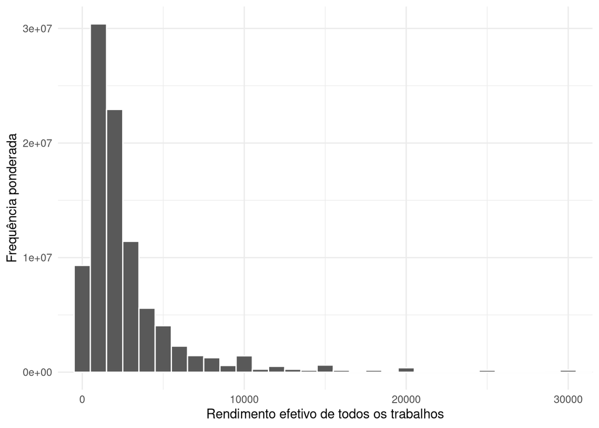

```r
ggplot(
  pnadc2023_1_df,
  aes(x = VD4020, weight = V1028)
) +
  geom_histogram(
    binwidth = 1000,
    color = "white"
  ) +
  coord_cartesian(xlim = c(0, 30000)) +
  labs(
    x = "Rendimento efetivo de todos os trabalhos",
    y = "Frequência ponderada"
  ) +
  theme_minimal()
```

A concentração de observações nos níveis inferiores e a presença de uma cauda superior longa ajudam a entender por que transformações logarítmicas são frequentes em equações de rendimento.

O logaritmo não é utilizado apenas por conveniência gráfica. Em uma regressão semilogarítmica, ele também permite interpretar o coeficiente associado a uma variável explicativa em termos aproximadamente percentuais.

## 12.11 6. Preparando a escolaridade

A variável `VD3005` aparece originalmente em categorias textuais. Para utilizá-la como uma medida numérica de anos de estudo, a rotina faz a recodificação:

```r
unique(pnadc2023_1_df$VD3005)
```

```
 [1] 12 anos de estudo
 [2] 16 anos ou mais de estudo
 [3] <NA>
 [4] 9 anos de estudo
 [5] 15 anos de estudo
 [6] 5 anos de estudo
 [7] 6 anos de estudo
 [8] Sem instrução e menos de 1 ano de estudo
 [9] 3 anos de estudo
[10] 7 anos de estudo
[11] 8 anos de estudo
[12] 4 anos de estudo
[13] 1 ano de estudo
[14] 10 anos de estudo
[15] 2 anos de estudo
[16] 13 anos de estudo
[17] 14 anos de estudo
[18] 11 anos de estudo
17 Levels: Sem instrução e menos de 1 ano de estudo ... 16 anos ou mais de estudo
```

```r
pnadc2023_1_df <- pnadc2023_1_df %>%
  mutate(
    VD3005 = case_when(
      VD3005 == "Sem instrução e menos de 1 ano de estudo" ~ "0",
      VD3005 == "1 ano de estudo" ~ "1",
      VD3005 == "2 anos de estudo" ~ "2",
      VD3005 == "3 anos de estudo" ~ "3",
      VD3005 == "4 anos de estudo" ~ "4",
      VD3005 == "5 anos de estudo" ~ "5",
      VD3005 == "6 anos de estudo" ~ "6",
      VD3005 == "7 anos de estudo" ~ "7",
      VD3005 == "8 anos de estudo" ~ "8",
      VD3005 == "9 anos de estudo" ~ "9",
      VD3005 == "10 anos de estudo" ~ "10",
      VD3005 == "11 anos de estudo" ~ "11",
      VD3005 == "12 anos de estudo" ~ "12",
      VD3005 == "13 anos de estudo" ~ "13",
      VD3005 == "14 anos de estudo" ~ "14",
      VD3005 == "15 anos de estudo" ~ "15",
      VD3005 == "16 anos ou mais de estudo" ~ "16",
      TRUE ~ VD3005
    )
  )

pnadc2023_1_df$VD3005 <-
  as.numeric(pnadc2023_1_df$VD3005)
```

A nova variável pode ser inspecionada com:

```r
summary(pnadc2023_1_df$VD3005)
```

```
   Min. 1st Qu.  Median    Mean 3rd Qu.    Max.    NA's
  0.000   5.000   9.000   8.518  12.000  16.000   27130
```

Essa transformação merece atenção. A última categoria da PNAD é “16 anos ou mais de estudo”, mas na variável numérica ela é representada por 16. Portanto, o valor numérico não distingue escolaridades acima desse limite.

## 12.12 7. Construindo uma medida de rendimento em relação às horas trabalhadas

As rotinas combinam `VD4017`, rendimento mensal efetivo no trabalho principal, e `V4039`, horas normalmente trabalhadas no trabalho principal:

```r
pnadc2023_1_df$SAL_HORA <-
  pnadc2023_1_df$VD4017 / pnadc2023_1_df$V4039
```

Na notação econométrica, chamaremos essa variável de $w_i$.

Antes de aplicar o logaritmo, são mantidos apenas valores positivos e finitos:

```r
base_modelos <- pnadc2023_1_df %>%
  filter(
    is.finite(SAL_HORA),
    SAL_HORA > 0,
    !is.na(VD3005)
  )
```

Essa seleção é necessária porque $\ln(w_i)$ não está definido para $w_i\leq 0$.

A amostra efetivamente utilizada nas regressões, portanto, não coincide necessariamente com a base completa da PNAD. O modelo é estimado para indivíduos para os quais as variáveis necessárias estão observadas e a transformação logarítmica é definida.

## 12.13 8. Da descrição para a regressão

A partir deste ponto, o interesse deixa de ser apenas a distribuição marginal das variáveis e passa a ser a relação entre elas.

A primeira quantidade de interesse pode ser escrita como

$$E[\ln(w_i)\mid s_i],
\tag{P.1}$$

em que:

- $w_i$ = medida de rendimento em relação às horas trabalhadas;
- $s_i$ = anos de escolaridade.

A função em (P.1) descreve o rendimento médio em logaritmo para diferentes níveis de escolaridade. Uma regressão linear fornece uma aproximação para essa função de esperança condicional:

$$\ln(w_i)
=
\alpha
+
\beta_1 s_i
+
u_i.
\tag{P.2}$$

Aqui:

- $\alpha$ = intercepto;
- $\beta_1$ = inclinação da associação entre escolaridade e log do rendimento;
- $u_i$ = diferença entre o valor observado e a parte representada pela regressão.

No R:

```r
modelo1 <- lm(
  log(SAL_HORA) ~ VD3005,
  data = base_modelos
)

summary(modelo1)
```

```
Call:
lm(formula = log(SAL_HORA) ~ VD3005, data = base_modelos)

Residuals:
    Min      1Q  Median      3Q     Max
-4.7727 -0.4940 -0.0410  0.4605  5.4448

Coefficients:
             Estimate Std. Error t value Pr(>|t|)
(Intercept) 2.9098848  0.0049331   589.9   <2e-16 ***
VD3005      0.0903285  0.0004254   212.4   <2e-16 ***
---
Signif. codes:  0 '***' 0.001 '**' 0.01 '*' 0.05 '.' 0.1 ' ' 1

Residual standard error: 0.7871 on 188601 degrees of freedom
Multiple R-squared:  0.193, Adjusted R-squared:  0.193
F-statistic: 4.509e+04 on 1 and 188601 DF,  p-value: < 2.2e-16
```

O coeficiente $\hat\beta_1$ resume a associação bivariada entre escolaridade e rendimento.

Como a variável dependente está em logaritmo, para valores pequenos de $\hat\beta_1$ a quantidade

$$100\hat\beta_1
\tag{P.3}$$

fornece uma aproximação da diferença percentual de rendimento associada a um ano adicional de escolaridade.

A transformação exata é

$$100\left[\exp(\hat\beta_1)-1\right].
\tag{P.4}$$

A linguagem correta é: **um ano adicional de escolaridade está associado a uma diferença média de rendimento**. O coeficiente não deve ser descrito como efeito causal da escolaridade.

## 12.14 9. O que muda quando condicionamos a comparação?

A comparação bivariada coloca lado a lado pessoas com diferentes níveis de escolaridade sem levar em conta outras características observadas.

A regressão múltipla permite condicionar essa comparação.

Defina

$$m_i=
\begin{cases}
1, & \text{se o indivíduo é mulher},\\
0, & \text{caso contrário}.
\end{cases}
\tag{P.5}$$

No banco:

```r
base_modelos <- base_modelos %>%
  mutate(
    dummy_sexo = ifelse(V2007 == "Mulher", 1, 0)
  )
```

O modelo passa a ser

$$\ln(w_i)
=
\alpha
+
\beta_1 s_i
+
\beta_2 m_i
+
u_i.
\tag{P.6}$$

No R:

```r
modelo2 <- lm(
  log(SAL_HORA) ~ VD3005 + dummy_sexo,
  data = base_modelos
)

summary(modelo2)
```

```
Call:
lm(formula = log(SAL_HORA) ~ VD3005 + dummy_sexo, data = base_modelos)

Residuals:
    Min      1Q  Median      3Q     Max
-4.8402 -0.4804 -0.0342  0.4499  5.4481

Coefficients:
              Estimate Std. Error t value Pr(>|t|)
(Intercept)  2.9397296  0.0049424  594.79   <2e-16 ***
VD3005       0.0945213  0.0004317  218.95   <2e-16 ***
dummy_sexo  -0.1790525  0.0037279  -48.03   <2e-16 ***
---
Signif. codes:  0 '***' 0.001 '**' 0.01 '*' 0.05 '.' 0.1 ' ' 1

Residual standard error: 0.7824 on 188600 degrees of freedom
Multiple R-squared:  0.2027,    Adjusted R-squared:  0.2027
F-statistic: 2.398e+04 on 2 and 188600 DF,  p-value: < 2.2e-16
```

Agora $\beta_1$ descreve a associação entre escolaridade e rendimento **condicionalmente ao sexo**.

O coeficiente $\beta_2$ descreve a diferença média de log do rendimento entre mulheres e homens para um mesmo nível de escolaridade, dentro da aproximação linear especificada.

Essa mudança de interpretação é central. O coeficiente da regressão múltipla não é simplesmente uma nova correlação bruta. Ele resume uma associação depois de manter constante, no modelo, a covariável incluída.

## 12.15 10. Correlação condicional não é causalidade

É tentador interpretar o controle estatístico como se ele produzisse automaticamente o *ceteris paribus* necessário para a causalidade. Essa interpretação é incorreta.

No modelo

$$\ln(w_i)
=
\alpha
+
\beta_1 s_i
+
\beta_2 m_i
+
u_i,$$

a inclusão de $m_i$ elimina da comparação a parte da variação associada linearmente ao sexo. Entretanto, muitas outras características podem continuar relacionadas simultaneamente à escolaridade e ao rendimento.

A regressão descreve

$$E[\ln(w_i)\mid s_i,m_i].
\tag{P.7}$$

Para interpretar $\beta_1$ como efeito causal seria necessário justificar uma condição muito mais forte, segundo a qual, dadas as variáveis de controle relevantes, a escolaridade poderia ser tratada como se fosse exógena em relação aos determinantes não observados do rendimento.

Essa condição não decorre do fato de termos incluído regressoras adicionais.

Por isso, neste capítulo:

$$\boxed{
\text{controle estatístico}
\;\neq\;
\text{identificação causal}
}
\tag{P.8}$$

## 12.16 11. Permitindo que a associação varie por sexo

O modelo anterior impõe que a inclinação de escolaridade seja a mesma para homens e mulheres. Essa restrição pode ser relaxada com um termo de interação:

$$\ln(w_i)
=
\alpha
+
\beta_1 s_i
+
\beta_2 m_i
+
\beta_3(s_i m_i)
+
u_i.
\tag{P.9}$$

No R:

```r
modelo3 <- lm(
  log(SAL_HORA) ~ VD3005 * dummy_sexo,
  data = base_modelos
)

summary(modelo3)
```

```
Call:
lm(formula = log(SAL_HORA) ~ VD3005 * dummy_sexo, data = base_modelos)

Residuals:
    Min      1Q  Median      3Q     Max
-4.8447 -0.4811 -0.0413  0.4441  5.4171

Coefficients:
                    Estimate Std. Error t value Pr(>|t|)
(Intercept)        2.9824353  0.0059359  502.44   <2e-16 ***
VD3005             0.0902737  0.0005416  166.68   <2e-16 ***
dummy_sexo        -0.3088777  0.0106754  -28.93   <2e-16 ***
VD3005:dummy_sexo  0.0116305  0.0008962   12.98   <2e-16 ***
---
Signif. codes:  0 '***' 0.001 '**' 0.01 '*' 0.05 '.' 0.1 ' ' 1

Residual standard error: 0.782 on 188599 degrees of freedom
Multiple R-squared:  0.2034,    Adjusted R-squared:  0.2034
F-statistic: 1.605e+04 on 3 and 188599 DF,  p-value: < 2.2e-16
```

Para homens, $m_i=0$, de modo que

$$E[\ln(w_i)\mid s_i,m_i=0]
=
\alpha+\beta_1s_i.
\tag{P.10}$$

Para mulheres, $m_i=1$:

$$E[\ln(w_i)\mid s_i,m_i=1]
=
(\alpha+\beta_2)
+
(\beta_1+\beta_3)s_i.
\tag{P.11}$$

Assim:

- $\beta_1$ é a inclinação associada à escolaridade para o grupo de referência;
- $\beta_2$ modifica o intercepto para mulheres;
- $\beta_3$ mede quanto a inclinação associada à escolaridade difere entre mulheres e homens;
- $\beta_1+\beta_3$ é a inclinação estimada para mulheres.

O termo de interação torna a regressão mais flexível. Ele não cria uma interpretação causal; apenas permite que a correlação condicional entre escolaridade e rendimento seja diferente entre os grupos.

## 12.17 12. Incorporando raça/cor à função de esperança condicional

A prática pode ser ampliada incorporando raça/cor como variável categórica.

No R:

```r
base_modelos <- base_modelos %>%
  mutate(
    raca_cor = relevel(
      factor(V2010),
      ref = "Branca"
    )
  )
```

O modelo é estimado por:

```r
modelo4 <- lm(
  log(SAL_HORA) ~ VD3005 + dummy_sexo + raca_cor,
  data = base_modelos
)

summary(modelo4)
```

```
Call:
lm(formula = log(SAL_HORA) ~ VD3005 + dummy_sexo + raca_cor,
    data = base_modelos)

Residuals:
    Min      1Q  Median      3Q     Max
-5.0089 -0.4662 -0.0370  0.4424  5.4767

Coefficients:
                  Estimate Std. Error t value Pr(>|t|)
(Intercept)       3.155761   0.005649 558.618   <2e-16 ***
VD3005            0.089253   0.000431 207.085   <2e-16 ***
dummy_sexo       -0.179900   0.003673 -48.982   <2e-16 ***
raca_corPreta    -0.265696   0.006104 -43.526   <2e-16 ***
raca_corAmarela  -0.050044   0.022043  -2.270   0.0232 *
raca_corParda    -0.277808   0.003833 -72.476   <2e-16 ***
raca_corIndígena -0.321300   0.026061 -12.329   <2e-16 ***
raca_corIgnorado  0.062414   0.151183   0.413   0.6797
---
Signif. codes:  0 '***' 0.001 '**' 0.01 '*' 0.05 '.' 0.1 ' ' 1

Residual standard error: 0.7708 on 188595 degrees of freedom
Multiple R-squared:  0.2262,    Adjusted R-squared:  0.2262
F-statistic:  7876 on 7 and 188595 DF,  p-value: < 2.2e-16
```

Em notação econométrica:

$$\ln(w_i)
=
\alpha
+
\beta_1s_i
+
\beta_2m_i
+
\sum_{j=2}^{J}\gamma_j r_{ji}
+
u_i.
\tag{P.12}$$

onde:

- $w_i$ = medida de rendimento;
- $s_i$ = anos de escolaridade;
- $m_i$ = indicador de mulher;
- $r_{ji}$ = indicador da categoria $j$ de raça/cor;
- $\gamma_j$ = diferença condicional associada à categoria $j$ em relação à categoria de referência;
- $u_i$ = componente residual.

A função de esperança condicional aproximada pela regressão passa a ser

$$E[\ln(w_i)\mid s_i,m_i,r_{2i},\ldots,r_{Ji}].
\tag{P.13}$$

Nesse contexto, $\beta_1$ representa a associação entre escolaridade e log do rendimento depois de condicionarmos a comparação pelas categorias de sexo e raça/cor incluídas no modelo.

Novamente, a palavra central é **condicional**.

## 12.18 13. Lendo a sequência das regressões

A utilidade da sequência de modelos está em observar como a descrição da relação empírica muda à medida que enriquecemos o conjunto de condicionantes.

O primeiro modelo,

$$\ln(w_i)=\alpha+\beta_1s_i+u_i,$$

resume uma associação bivariada.

O segundo,

$$\ln(w_i)
=
\alpha+\beta_1s_i+\beta_2m_i+u_i,$$

passa a comparar níveis de escolaridade condicionando por sexo.

O terceiro,

$$\ln(w_i)
=
\alpha
+\beta_1s_i
+\beta_2m_i
+\beta_3(s_im_i)
+u_i,$$

permite que a própria inclinação da relação entre escolaridade e rendimento varie por sexo.

O quarto,

$$\ln(w_i)
=
\alpha
+\beta_1s_i
+\beta_2m_i
+\sum_{j=2}^{J}\gamma_jr_{ji}
+u_i,$$

amplia a função de esperança condicional com indicadores de raça/cor.

A comparação dos coeficientes entre especificações mostra quanto a associação inicialmente observada é sensível à inclusão de novas covariáveis. Essa comparação é informativa sobre a estrutura dos dados, mas não constitui, por si só, teste de causalidade.

## 12.19 14. Resíduos e heterocedasticidade

Depois da estimação, é útil observar os resíduos.

Para o primeiro modelo:

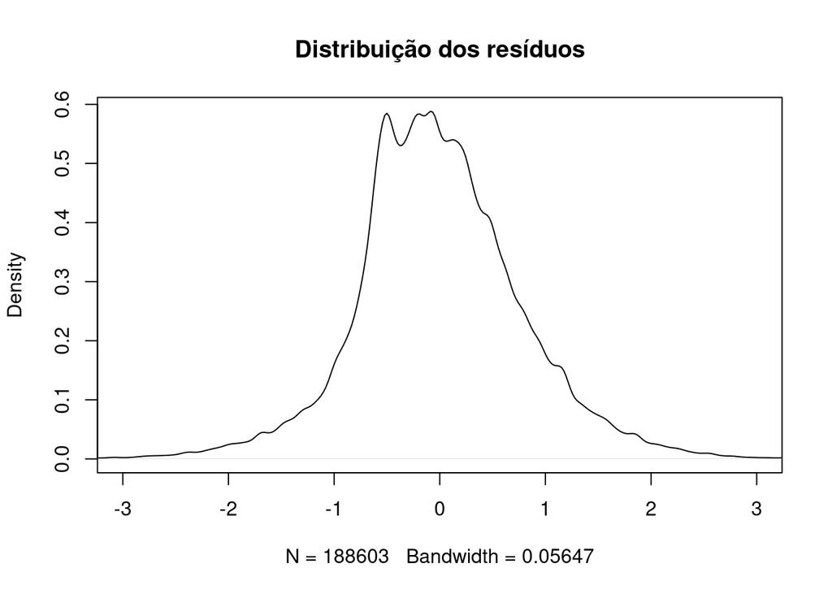

```r
resid_modelo1 <- residuals(modelo1)

plot(
  density(resid_modelo1, kernel = "gaussian"),
  main = "Distribuição dos resíduos",
  xlim = c(-3, 3)
)
```

A relação entre resíduos e valores ajustados pode ser inspecionada por:

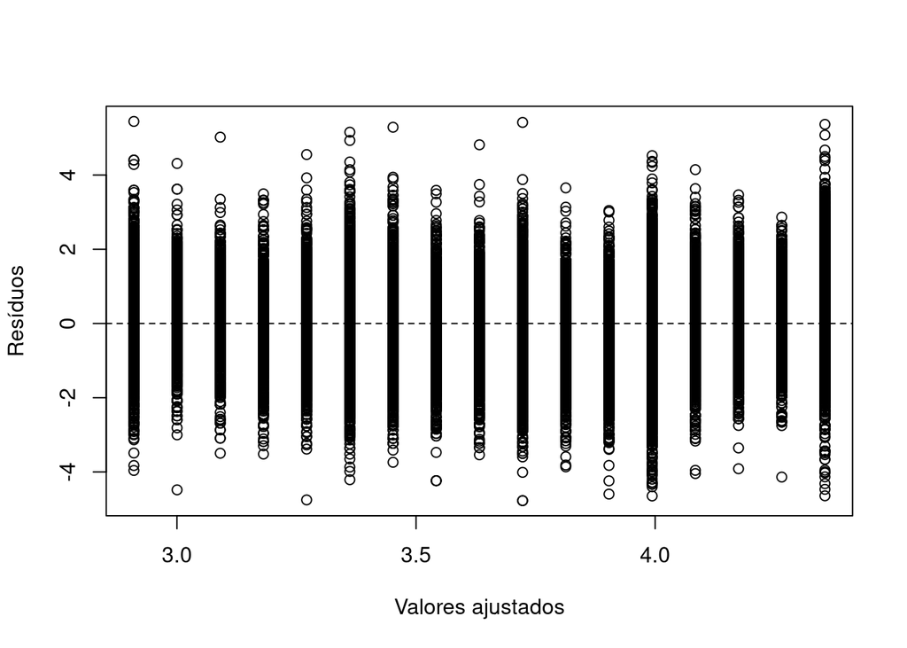

```r
plot(
  fitted(modelo1),
  residuals(modelo1),
  xlab = "Valores ajustados",
  ylab = "Resíduos"
)

abline(h = 0, lty = 2)
```

Um gráfico quantil-quantil é obtido com:

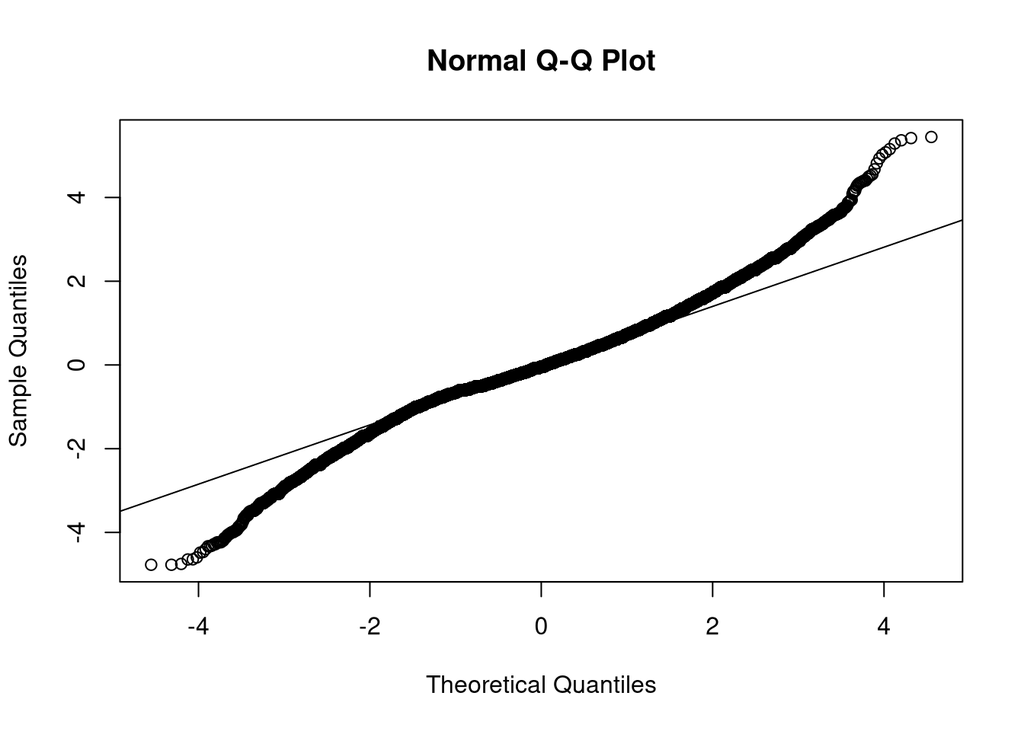

```r
qqnorm(resid_modelo1)
qqline(resid_modelo1)
```

Esses diagnósticos dizem respeito ao comportamento estatístico dos resíduos e à adequação da aproximação. Eles não dizem se a regressão possui interpretação causal.

## 12.20 15. Erros-padrão robustos

Com microdados individuais, a variância dos resíduos pode variar sistematicamente entre observações. Nesse caso, a hipótese de homocedasticidade,

$$E[u_i^2\mid x_i]=\sigma^2,
\tag{P.14}$$

pode não ser adequada.

Aqui, $x_i$ representa o conjunto de regressoras incluídas no modelo.

As rotinas utilizam o teste de Breusch-Pagan:

```r
bptest(modelo1)
```

```
    studentized Breusch-Pagan test

data:  modelo1
BP = 31.371, df = 1, p-value = 2.132e-08
```

Também calculamos uma matriz de variância-covariância robusta à heterocedasticidade:

```r
vcov_robusta1 <- vcovHC(
  modelo1,
  type = "HC1"
)

coeftest(
  modelo1,
  vcov. = vcov_robusta1
)
```

```
t test of coefficients:

              Estimate Std. Error t value  Pr(>|t|)
(Intercept) 2.90988481 0.00531784  547.19 < 2.2e-16 ***
VD3005      0.09032852 0.00046725  193.32 < 2.2e-16 ***
---
Signif. codes:  0 '***' 0.001 '**' 0.01 '*' 0.05 '.' 0.1 ' ' 1
```

Intervalos de confiança robustos podem ser obtidos com:

```r
coefci(
  modelo1,
  vcov. = vcov_robusta1
)
```

```
                 2.5 %     97.5 %
(Intercept) 2.89946197 2.92030766
VD3005      0.08941272 0.09124431
```

O mesmo procedimento pode ser aplicado às demais especificações:

```r
vcov_robusta2 <- vcovHC(modelo2, type = "HC1")
vcov_robusta3 <- vcovHC(modelo3, type = "HC1")
vcov_robusta4 <- vcovHC(modelo4, type = "HC1")

coeftest(modelo2, vcov. = vcov_robusta2)
```

```
t test of coefficients:

               Estimate  Std. Error t value  Pr(>|t|)
(Intercept)  2.93972956  0.00531928 552.655 < 2.2e-16 ***
VD3005       0.09452133  0.00048004 196.903 < 2.2e-16 ***
dummy_sexo  -0.17905250  0.00374550 -47.805 < 2.2e-16 ***
---
Signif. codes:  0 '***' 0.001 '**' 0.01 '*' 0.05 '.' 0.1 ' ' 1
```

```r
coeftest(modelo3, vcov. = vcov_robusta3)
```

```
t test of coefficients:

                     Estimate  Std. Error t value  Pr(>|t|)
(Intercept)        2.98243528  0.00639928  466.06 < 2.2e-16 ***
VD3005             0.09027372  0.00060265  149.80 < 2.2e-16 ***
dummy_sexo        -0.30887775  0.01179812  -26.18 < 2.2e-16 ***
VD3005:dummy_sexo  0.01163054  0.00100263   11.60 < 2.2e-16 ***
---
Signif. codes:  0 '***' 0.001 '**' 0.01 '*' 0.05 '.' 0.1 ' ' 1
```

```r
coeftest(modelo4, vcov. = vcov_robusta4)
```

```
t test of coefficients:

                    Estimate  Std. Error  t value Pr(>|t|)
(Intercept)       3.15576085  0.00596752 528.8226  < 2e-16 ***
VD3005            0.08925335  0.00047689 187.1570  < 2e-16 ***
dummy_sexo       -0.17989991  0.00369054 -48.7462  < 2e-16 ***
raca_corPreta    -0.26569574  0.00593995 -44.7303  < 2e-16 ***
raca_corAmarela  -0.05004404  0.02381914  -2.1010  0.03564 *
raca_corParda    -0.27780817  0.00383120 -72.5120  < 2e-16 ***
raca_corIndígena -0.32130026  0.02702313 -11.8898  < 2e-16 ***
raca_corIgnorado  0.06241413  0.19545991   0.3193  0.74948
---
Signif. codes:  0 '***' 0.001 '**' 0.01 '*' 0.05 '.' 0.1 ' ' 1
```

## 12.21 16. Comparando as especificações

As quatro regressões podem ser apresentadas lado a lado.

Primeiro, extraímos os erros-padrão robustos:

```r
se1 <- sqrt(diag(vcov_robusta1))
se2 <- sqrt(diag(vcov_robusta2))
se3 <- sqrt(diag(vcov_robusta3))
se4 <- sqrt(diag(vcov_robusta4))
```

Depois:

```r
stargazer(
  modelo1,
  modelo2,
  modelo3,
  modelo4,
  type = "text",
  se = list(se1, se2, se3, se4),
  title = "Escolaridade e rendimento: associações condicionais",
  align = TRUE
)
```

```
Escolaridade e rendimento: associações condicionais
==============================================================================================================================================
                                                                       Dependent variable:
                    --------------------------------------------------------------------------------------------------------------------------
                                                                          log(SAL_HORA)
                                 (1)                            (2)                            (3)                            (4)
----------------------------------------------------------------------------------------------------------------------------------------------
VD3005                         0.090***                       0.095***                       0.090***                      0.089***
                               (0.0005)                       (0.0005)                       (0.001)                       (0.0005)

dummy_sexo                                                   -0.179***                      -0.309***                      -0.180***
                                                              (0.004)                        (0.012)                        (0.004)

VD3005:dummy_sexo                                                                            0.012***
                                                                                             (0.001)

raca_corPreta                                                                                                              -0.266***
                                                                                                                            (0.006)

raca_corAmarela                                                                                                            -0.050**
                                                                                                                            (0.024)

raca_corParda                                                                                                              -0.278***
                                                                                                                            (0.004)

raca_corIndígena                                                                                                           -0.321***
                                                                                                                            (0.027)

raca_corIgnorado                                                                                                             0.062
                                                                                                                            (0.195)

Constant                       2.910***                       2.940***                       2.982***                      3.156***
                               (0.005)                        (0.005)                        (0.006)                        (0.006)

----------------------------------------------------------------------------------------------------------------------------------------------
Observations                   188,603                        188,603                        188,603                        188,603
R2                              0.193                          0.203                          0.203                          0.226
Adjusted R2                     0.193                          0.203                          0.203                          0.226
Residual Std. Error      0.787 (df = 188601)            0.782 (df = 188600)            0.782 (df = 188599)            0.771 (df = 188595)
F Statistic         45,093.630*** (df = 1; 188601) 23,975.940*** (df = 2; 188600) 16,054.290*** (df = 3; 188599) 7,876.139*** (df = 7; 188595)
==============================================================================================================================================
Note:                                                                                                              *p<0.1; **p<0.05; ***p<0.01
```

A leitura da tabela deve acompanhar a lógica econômica das especificações. O interesse não está apenas em verificar se um coeficiente é estatisticamente diferente de zero. É preciso observar:

- o sinal da associação;
- sua magnitude;
- sua estabilidade entre especificações;
- a precisão das estimativas;
- o significado das categorias de referência;
- o papel das interações.

Uma mudança do coeficiente de escolaridade após a inclusão de sexo ou raça/cor mostra que a associação bivariada e a associação condicional não são idênticas. Isso é uma propriedade empírica da amostra e do modelo.

## 12.22 17. A função de esperança condicional como fio condutor

A sequência desta prática pode ser entendida como uma aproximação progressivamente mais rica da função de esperança condicional.

Inicialmente:

$$E[\ln(w_i)\mid s_i].
\tag{P.15}$$

Depois:

$$E[\ln(w_i)\mid s_i,m_i].
\tag{P.16}$$

E, por fim:

$$E[\ln(w_i)\mid s_i,m_i,r_{2i},\ldots,r_{Ji}].
\tag{P.17}$$

Essa é uma forma particularmente útil de compreender regressão com dados observacionais.

As covariáveis permitem comparar pessoas dentro de grupos cada vez mais específicos definidos por características observadas. A regressão organiza essas comparações em uma forma estatística simples e produz uma aproximação linear para as médias condicionais.

O que ela não faz automaticamente é resolver diferenças não observadas entre indivíduos.

## 12.23 18. Por que esta prática não é um estudo causal?

A questão causal correspondente seria algo como:

> Quanto mudaria o rendimento de uma mesma pessoa se fosse possível aumentar sua escolaridade, mantendo os demais determinantes relevantes constantes?

Essa pergunta envolve um contrafactual.

Os microdados da PNAD mostram pessoas diferentes com escolaridades diferentes. A comparação entre elas pode ser refinada condicionando por características observadas, mas não temos, nesta prática, um mecanismo que atribua escolaridade aleatoriamente nem outra estratégia de identificação que justifique tratá-la como exógena.

Assim, o modelo

$$\ln(w_i)
=
\alpha+\beta_1s_i+x_i'\gamma+u_i
\tag{P.18}$$

não autoriza, por sua forma algébrica, a interpretação de $\beta_1$ como efeito causal.

Aqui:

- $w_i$ = rendimento;
- $s_i$ = escolaridade;
- $x_i$ = vetor de covariáveis observadas;
- $u_i$ = fatores não representados pelas regressoras.

Para uma interpretação causal seria necessário justificar que a variação relevante em $s_i$, depois de condicionarmos por $x_i$, não está sistematicamente relacionada aos determinantes não observados incorporados em $u_i$. Essa justificativa não é fornecida apenas pela inclusão de controles.

## 12.24 19. Como relatar os resultados

A linguagem do relatório deve refletir exatamente o tipo de evidência produzida.

Formulações adequadas incluem:

> Escolaridade apresenta associação positiva com o rendimento.

> A associação permanece após condicionarmos a comparação por sexo e raça/cor.

> O coeficiente associado à escolaridade se modifica após a inclusão das covariáveis.

> Mulheres apresentam, em média, diferença de rendimento em relação aos homens, condicionalmente às demais variáveis incluídas na especificação.

> A interação indica que a inclinação da associação entre escolaridade e rendimento difere entre homens e mulheres.

Formulações causais, como “um ano adicional de escolaridade aumenta o rendimento” ou “ser mulher reduz o salário”, não são sustentadas por esta estratégia empírica.

## 12.25 20. O percurso completo da prática

A análise desenvolvida neste capítulo segue uma sequência que é comum em estudos com microdados:

$$\boxed{
\text{pergunta empírica}
\rightarrow
\text{microdados}
\rightarrow
\text{construção das variáveis}
\rightarrow
\text{descrição}
\rightarrow
\text{regressão}
\rightarrow
\text{correlação condicional}
}
\tag{P.19}$$

O passo decisivo é compreender onde essa sequência termina.

Neste caso, ela termina na **correlação condicional**.

Uma sequência causal exigiria um elemento adicional:

$$\boxed{
\text{pergunta causal}
\rightarrow
\text{experimento ideal}
\rightarrow
\text{estratégia de identificação}
\rightarrow
\text{estimação}
\rightarrow
\text{efeito causal}
}
\tag{P.20}$$

Essa distinção conecta diretamente a prática empírica aos fundamentos discutidos nos capítulos anteriores. A econometria não consiste apenas em estimar regressões. Consiste em saber qual pergunta está sendo respondida, quais comparações os dados permitem fazer e até onde a interpretação pode ir.

## 12.26 21. Uma limitação em aberto: o desenho amostral

Todas as regressões estimadas até aqui (`modelo1` a `modelo4`) foram ajustadas por `lm()` sobre `base_modelos`, um `data.frame` comum. Esse procedimento ignora dois aspectos do desenho amostral da PNAD Contínua:

1. os **pesos amostrais** (`V1028`), que fazem cada observação representar um número diferente de pessoas na população;
2. a **estratificação e a conglomeração** da amostra, que fazem com que observações dentro do mesmo estrato/UPA não sejam independentes entre si.

O objeto `pnadc_2023_1`, criado por `get_pnadc()`, já contém essas informações. A seção seguinte refaz a análise incorporando esse desenho amostral com a biblioteca `survey`, e compara os resultados com o que foi obtido por `lm()`.

## 12.27 Comparação com a biblioteca `survey`

### 12.27.1 Por que `lm()` e `survey` respondem perguntas diferentes

`lm()` estima os coeficientes tratando cada linha da base como uma observação independente e igualmente informativa, a menos que um peso seja explicitamente incluído via `weights =`. Os erros-padrão robustos (HC1) calculados na Seção 15 corrigem a heterocedasticidade condicional, mas continuam supondo observações independentes.

A biblioteca `survey` foi construída especificamente para inferência em pesquisas amostrais complexas. Ela usa os pesos, os estratos e as unidades primárias de amostragem para:

- calcular médias, proporções e totais que estimam corretamente parâmetros populacionais;
- calcular erros-padrão que refletem a perda (ou o ganho) de precisão associado à conglomeração e à estratificação — o chamado *efeito de desenho* (*design effect*).

Em outras palavras: `lm()` com pesos ajusta a média estimada, mas não corrige a inferência para a dependência entre observações do mesmo estrato/UPA; `svyglm()` faz as duas coisas.

### 12.27.2 Preparando o desenho amostral

As variáveis criadas em `base_modelos` (`SAL_HORA`, `dummy_sexo`, `raca_cor`) precisam ser recriadas sobre o objeto de desenho amostral, e não apenas sobre o `data.frame` extraído:

```r
pnadc_2023_1 <- update(
  pnadc_2023_1,
  VD3005 = case_when(
    VD3005 == "Sem instrução e menos de 1 ano de estudo" ~ 0,
    VD3005 == "1 ano de estudo" ~ 1,
    VD3005 == "2 anos de estudo" ~ 2,
    VD3005 == "3 anos de estudo" ~ 3,
    VD3005 == "4 anos de estudo" ~ 4,
    VD3005 == "5 anos de estudo" ~ 5,
    VD3005 == "6 anos de estudo" ~ 6,
    VD3005 == "7 anos de estudo" ~ 7,
    VD3005 == "8 anos de estudo" ~ 8,
    VD3005 == "9 anos de estudo" ~ 9,
    VD3005 == "10 anos de estudo" ~ 10,
    VD3005 == "11 anos de estudo" ~ 11,
    VD3005 == "12 anos de estudo" ~ 12,
    VD3005 == "13 anos de estudo" ~ 13,
    VD3005 == "14 anos de estudo" ~ 14,
    VD3005 == "15 anos de estudo" ~ 15,
    VD3005 == "16 anos ou mais de estudo" ~ 16,
    TRUE ~ NA_real_
  ),
  SAL_HORA = VD4017 / V4039,
  dummy_sexo = ifelse(V2007 == "Mulher", 1, 0),
  raca_cor = relevel(factor(V2010), ref = "Branca")
)
```

A restrição à subamostra utilizada nas regressões (valores finitos e positivos de `SAL_HORA`, escolaridade não faltante) é aplicada com `subset()`, que preserva a estrutura do desenho amostral — diferente de um `filter()` aplicado a um `data.frame` comum:

```r
desenho_modelos <- subset(
  pnadc_2023_1,
  is.finite(SAL_HORA) & SAL_HORA > 0 & !is.na(VD3005)
)
```

### 12.27.3 Estatísticas descritivas com desenho amostral

A média de `VD4020` pode ser recalculada diretamente do desenho amostral, sem a necessidade de indicar manualmente o peso:

```r
svymean(~VD4020, design = pnadc_2023_1, na.rm = TRUE)
```

```
         mean     SE
VD4020 3099.7 31.338
```

O resultado numérico coincide com `weighted.mean(VD4020, w = V1028)` calculado na Seção 4, mas `svymean()` já reporta um erro-padrão que incorpora estratos e conglomerados — algo que `weighted.mean()` não calcula.

As médias por raça/cor também podem ser obtidas com o desenho amostral:

```r
svyby(
  ~VD4016,
  ~raca_cor,
  design = pnadc_2023_1,
  svymean,
  na.rm = TRUE
)
```

```
         raca_cor   VD4016         se
Branca     Branca 3531.480   50.30580
Preta       Preta 2156.921   26.93303
Amarela   Amarela 3949.790  200.36857
Parda       Parda 2168.117   15.67235
Indígena Indígena 1987.407   99.98301
Ignorado Ignorado 6273.753 1960.61904
```

### 12.27.4 Reestimando os quatro modelos com `svyglm()`

Os mesmos quatro modelos da Seção 8 em diante são reestimados substituindo `lm()` por `svyglm()` e `data = base_modelos` por `design = desenho_modelos`:

```r
svymodelo1 <- svyglm(
  log(SAL_HORA) ~ VD3005,
  design = desenho_modelos
)

svymodelo2 <- svyglm(
  log(SAL_HORA) ~ VD3005 + dummy_sexo,
  design = desenho_modelos
)

svymodelo3 <- svyglm(
  log(SAL_HORA) ~ VD3005 * dummy_sexo,
  design = desenho_modelos
)

svymodelo4 <- svyglm(
  log(SAL_HORA) ~ VD3005 + dummy_sexo + raca_cor,
  design = desenho_modelos
)

summary(svymodelo1)
```

```
Call:
svyglm(formula = log(SAL_HORA) ~ VD3005, design = desenho_modelos)

Survey design:
subset(pnadc_2023_1, is.finite(SAL_HORA) & SAL_HORA > 0 & !is.na(VD3005))

Coefficients:
             Estimate Std. Error t value Pr(>|t|)
(Intercept) 2.8821891  0.0101309  284.49   <2e-16 ***
VD3005      0.0954615  0.0009988   95.58   <2e-16 ***
---
Signif. codes:  0 '***' 0.001 '**' 0.01 '*' 0.05 '.' 0.1 ' ' 1

(Dispersion parameter for gaussian family taken to be 0.5908777)

Number of Fisher Scoring iterations: 2
```

```r
summary(svymodelo2)
```

```
Call:
svyglm(formula = log(SAL_HORA) ~ VD3005 + dummy_sexo, design = desenho_modelos)

Survey design:
subset(pnadc_2023_1, is.finite(SAL_HORA) & SAL_HORA > 0 & !is.na(VD3005))

Coefficients:
             Estimate Std. Error t value Pr(>|t|)
(Intercept)  2.920215   0.009977  292.69   <2e-16 ***
VD3005       0.099427   0.001023   97.23   <2e-16 ***
dummy_sexo  -0.193798   0.004758  -40.73   <2e-16 ***
---
Signif. codes:  0 '***' 0.001 '**' 0.01 '*' 0.05 '.' 0.1 ' ' 1

(Dispersion parameter for gaussian family taken to be 0.5819315)

Number of Fisher Scoring iterations: 2
```

```r
summary(svymodelo3)
```

```
Call:
svyglm(formula = log(SAL_HORA) ~ VD3005 * dummy_sexo, design = desenho_modelos)

Survey design:
subset(pnadc_2023_1, is.finite(SAL_HORA) & SAL_HORA > 0 & !is.na(VD3005))

Coefficients:
                   Estimate Std. Error t value Pr(>|t|)
(Intercept)        2.952103   0.010867 271.658  < 2e-16 ***
VD3005             0.096459   0.001101  87.644  < 2e-16 ***
dummy_sexo        -0.284568   0.016184 -17.583  < 2e-16 ***
VD3005:dummy_sexo  0.007853   0.001319   5.954 1.19e-08 ***
---
Signif. codes:  0 '***' 0.001 '**' 0.01 '*' 0.05 '.' 0.1 ' ' 1

(Dispersion parameter for gaussian family taken to be 0.5817109)

Number of Fisher Scoring iterations: 2
```

```r
summary(svymodelo4)
```

```
Call:
svyglm(formula = log(SAL_HORA) ~ VD3005 + dummy_sexo + raca_cor,
    design = desenho_modelos)

Survey design:
subset(pnadc_2023_1, is.finite(SAL_HORA) & SAL_HORA > 0 & !is.na(VD3005))

Coefficients:
                   Estimate Std. Error t value Pr(>|t|)
(Intercept)       3.1321511  0.0096720 323.836  < 2e-16 ***
VD3005            0.0933945  0.0009275 100.696  < 2e-16 ***
dummy_sexo       -0.1944488  0.0048085 -40.438  < 2e-16 ***
raca_corPreta    -0.2567914  0.0089555 -28.674  < 2e-16 ***
raca_corAmarela   0.0284699  0.0370230   0.769    0.443
raca_corParda    -0.2642661  0.0061074 -43.270  < 2e-16 ***
raca_corIndígena -0.2914743  0.0404162  -7.212 1.24e-11 ***
raca_corIgnorado  0.1657576  0.2292571   0.723    0.471
---
Signif. codes:  0 '***' 0.001 '**' 0.01 '*' 0.05 '.' 0.1 ' ' 1

(Dispersion parameter for gaussian family taken to be 0.5652853)

Number of Fisher Scoring iterations: 2
```

A forma da equação estimada é exatamente a mesma apresentada nas equações (P.2), (P.6), (P.9) e (P.12). O que muda é a forma como a variabilidade amostral é levada em conta na construção do erro-padrão de $\hat\beta$.

### 12.27.5 Tabela síntese: com e sem a biblioteca `survey`

Escolaridade e rendimento: comparação entre `lm()` e `svyglm()`

| Especificação | $\hat{\beta}_1$ — `lm()` | EP — `lm()` | $\hat{\beta}_1$ — `svyglm()` | EP — `svyglm()` |
| --- | --- | --- | --- | --- |
| Modelo 1 | 0.0903 | (0.0005) | 0.0955 | (0.0010) |
| Modelo 2 | 0.0945 | (0.0005) | 0.0994 | (0.0010) |
| Modelo 3 | 0.0903 | (0.0006) | 0.0965 | (0.0011) |
| Modelo 4 | 0.0893 | (0.0005) | 0.0934 | (0.0009) |

A leitura desta tabela reforça um ponto já anunciado na Seção 15: erros-padrão robustos à heterocedasticidade **não substituem** o uso do desenho amostral. Eles resolvem problemas diferentes. Heterocedasticidade diz respeito à variância do erro condicional às covariáveis; desenho amostral diz respeito à forma como a amostra foi selecionada da população.

| Aspecto | `lm()` sem `survey` | `svyglm()` com `survey` |
| --- | --- | --- |
| Uso do peso amostral (`V1028`) | Ignorado nas regressões (usado apenas nas estatísticas descritivas) | Incorporado automaticamente via o objeto de desenho |
| Estratificação/conglomeração | Não considerada | Considerada no cálculo dos erros-padrão |
| Ponto estimado $\hat\beta_1$ | Pode diferir do estimado com pesos, pois cada observação recebe peso implícito igual a 1 | Reflete a estrutura populacional representada pela amostra |
| Erro-padrão convencional | Assume homocedasticidade e independência | Não é a referência correta para dados de pesquisa amostral complexa |
| Erro-padrão robusto HC1 | Corrige heterocedasticidade, mas ainda assume independência entre observações | — |
| Erro-padrão com desenho amostral | Não calculado | Incorpora heterocedasticidade, pesos e dependência dentro de estrato/UPA |
| Interpretação do coeficiente | Associação na amostra analítica utilizada | Associação estimada para a população representada pela PNAD Contínua |
| Uso recomendado | Explorar rapidamente a base, verificar sensibilidade a especificações | Reportar resultados quando o objetivo é uma inferência válida sobre a população |

Nenhuma das duas colunas da tabela transforma $\hat\beta_1$ em efeito causal. A incorporação do desenho amostral melhora a validade da inferência sobre a **associação populacional**, mas não resolve o problema discutido nas Seções 10 e 18: a ausência de uma estratégia de identificação causal.

## 12.28 Síntese

A PNAD Contínua oferece um ambiente especialmente útil para compreender a econometria aplicada com dados observacionais. Seus microdados permitem trabalhar com amostras grandes, variáveis econômicas relevantes e heterogeneidade individual.

Nesta prática, a regressão é utilizada para quatro finalidades principais.

Primeiro, resumir a associação entre escolaridade e rendimento.

Segundo, transformar uma associação bivariada em uma associação condicional, incorporando características observadas como sexo e raça/cor.

Terceiro, mostrar como a especificação econométrica modifica a interpretação dos coeficientes, especialmente quando são introduzidas variáveis indicadoras e termos de interação.

Quarto, mostrar que a forma de incorporar a estrutura amostral da pesquisa — pesos, estratos e conglomerados — afeta a precisão (e, em menor medida, o ponto estimado) das associações relatadas, sem alterar o alcance interpretativo dos coeficientes.

A principal conclusão metodológica é simples: **uma regressão múltipla pode produzir uma comparação estatisticamente mais condicionada, e o uso da biblioteca `survey` pode produzir uma inferência mais adequada ao desenho amostral, sem que nenhuma das duas coisas produza, por si só, uma comparação causal**. O valor da análise está justamente em reconhecer com precisão o alcance da evidência produzida.

# 13 Estimação de Variáveis Instrumentais

**Pacotes utilizados neste capítulo.** Os exemplos usam o `AER` (função `ivreg()` para a estimação por variáveis instrumentais), o `lmtest` (função `coeftest()`), o `stargazer` (tabelas comparativas) e o `wooldridge`, de onde vêm as bases `mroz` e `card`. Todos são carregados no bloco abaixo.

**Mostrar pacotes utilizados neste capítulo**

```r
pacotes <- c(
  "AER",
  "lmtest",
  "stargazer",
  "wooldridge"
)

for (pacote in pacotes) {
  if (!requireNamespace(pacote, quietly = TRUE)) {
    install.packages(pacote, dependencies = TRUE)
  }
  library(pacote, character.only = TRUE)
}
```

## 13.1 O problema de variáveis omitidas em um modelo de regressão simples

Na possibilidade de viés de variáveis omitidas (ou heterogeneidade não observada) há pelo menos 4 opções: 1) podemos ignorar o problema e sofrer as consequência de estimadores viesados e inconsistentes; 2) podemos tentar encontrar e usar uma varável *proxy* adequada da variável não observada; ou 3) podemos presumir que a variável omitida não se altera ao longo do tempo e utilizar um modelo de efeitos fixos ou de primeira diferença; 4) deixar a variável não observada no termo de erro, mas, em vez de estimar por MQO, usa-se um método que reconheça a presença da variável omitida. É isso que o método de IV faz.

Considere o problema da aptidão não observada em uma equação de salários-hora (*wage*) de trabalhadores adultos. Uma regressão curta é

$$\log(wage)=\beta_0 + \beta_1 educ + \beta_2 aptid + e.
\tag{1}$$

em que $e$ é o termo de erro.

Sob certas hipóteses, uma variável *proxy* como *IQ* pode substituir a aptidão, e assim um estimador consistente de $\beta_1$ será obtido a partir da regressão

$$\log(wage)=\beta_0 + \beta_1 educ + \beta_2 IQ + e.
\tag{2}$$

Na falta de uma boa variável *proxy*, colocamos *aptid* no termo de erro e ficamos com o modelo de regressão simples:

$$\log(wage)=\beta_0 + \beta_1 educ + u.
\tag{3}$$

em que $u$ contém *aptid*. Naturalmente, se a equação 1 for estimada por OLS, o resultado será um estimador viesado e inconsistente de $\beta_1$, se *educ* e *aptid* forem correlacionados.

Uma saída, neste caso, é usar estimar a equação 1 usando uma variável instrumental para a *educ*.

## 13.2 Estimador de IV em um modelo de regressão simples

Considere um modelo de regressão simples

$$y=\beta_0 + \beta_1 x + u.
\tag{4}$$

em que acreditamos que $x$ e $u$ são correlacionados, ou seja:

$$\text{Cov}(x,u) \neq 0.
\tag{5}$$

Nessa situação, para obter estimadores consistentes de $\beta_0$ e $\beta_1$, necessitamos de alguma informação adicional. Suponha que tenhamos um variável observável $z$ que satisfaça as duas propriedades (ou hipóteses):

$$\text{Cov}(z,u) = 0.
\tag{6}$$

e

$$\text{Cov}(z,x) \neq 0.
\tag{7}$$

Então, dizemos que $z$ é uma **variável instrumental** de $x$ (ou simplesmente, **instrumento** de $x$).

Quando o instrumento $z$ satisfaz a condição de $\text{Cov}(z,u) = 0$, dizemos que “$z$ é exógena na equação 4”; assim nos referimos a 6 como **exogeneidade dos instrumentos**. A condição 7 é referida como **relevância dos instrumentos** (isto é, “como $z$ é relevante para explicar a variação em $x$”).

Como 6 envolve uma variável não observável, $u$, em geral temos que sustentar $\text{Cov}(z,u) = 0$ recorrendo ao comportamento ou à introspecção econômica. Por outro lado, a condição $\text{Cov}(z,x) \neq 0$ pode ser testada. A maneira mais simples de fazer isso é estimar uma regressão simples entre $x$ e $y$. Na população, temos:

$$x=\pi_0+\pi_1z+\nu
\tag{8}$$

Então, como $\pi_1=\text{Cov}(z,x)/\text{Var}(z)$, a hipótese 7 será válida se, e somente se, $\pi_1 \neq 0$. Assim, devemos rejeitar a hipótese nula

$$\text{H}_0:\pi_1=0
\tag{9}$$

contra a alternativa $\text{H}_0:\pi_1 \neq 0$ a um nível de significância suficientemente pequeno (5% ou 1%).

Para a equação de salários em 3, uma variável instrumental $z$ de $educ$ deve ser: (1) Não correlacionada com aptidão e (2) correlacionada com a educação. Algo como o último dígito do número da previdência social dos indivíduos é um **instrumento relevante**?

Tenha em mente que o chamamos de variável *proxy* da variável omitida transforma-se em um VI fraca pela por não respeitar a hipótese em 6, ou seja, por violar o requisito da exogeneidade do instrumento: $\text{Cov}(z,u) = 0$.

A disponibilidade de uma VI relevante pode ser usada para estimar com **consistência** os parâmetros da equação 4:

$$y=\beta_0 + \beta_1 x + u.$$

As hipóteses expressas em 6 e 7 servem para **identificar** o parâmetro $\beta_1$ aplicando:

$$\beta_1=\frac{\text{Cov}(z,y)}{\text{Cov}(z,x)}
\tag{10}$$

Observe que se a condição 7 $\text{Cov}(z,x) \neq 0$ (de relevância do instrumento) for violada, então $\beta_1$ não pode ser identificado. Dada uma amostra de dados $y$, $x$ e $z$, **o estimador de variáveis instrumentais** de $\beta_1$:

$$\beta_1=\frac{\text{Cov}(z_i,y_i)}{\text{Cov}(z_i,x_i)}
\tag{11}$$

e para $\beta_0$ será $\hat{\beta_0}=\bar{y} - \hat{\beta_1} \bar{x}$.

Observe que quando $z=x$ obtemos o estimador OLS de $\beta_1$, e consequentemente de $\beta_0$. Em outras palavras quando $x$ é exógeno, ele pode ser usado como seu próprio instrumento, e o estimador de VI será idêntico ao estimador OLS.

### 13.2.1 Exemplo 1

Utilizaremos os **dados sobre mulheres casadas que trabalham**, contidos no arquivo `mroz`, para estimar o retorno da educação no modelo de regressão simples (Wooldridge 2003; Exemplo 15.1)

$$\log(wage)=\beta_0 + \beta_1 educ + u.
\tag{12}$$

Usaremos a educação do pai (*fatheeduc*) como uma variável instrumental de *educ*. Temos que sustentar que *fatheduc* é não correlacionado com *u*. O segundo requisito é que *educ* e *fatheduc* sejam correlacionados. Podemos verificar isso facilmente, usando uma regressão simples de *educ* sobre *fatheduc* (utilizando somente as mulheres que trabalham na amostra.

```r
# Wooldridge 2003: Exemplo 15.1
# dados s/ mulheres casadas que trabalham
data(mroz, package='wooldridge')
```

```r
# Restringindo à observações salariais não missings
oursample <- subset(mroz, !is.na(wage))
```

```r
# Obtendo o parâmetro de inclinação OLS manualmente
with(oursample,
     cov(log(wage),educ)/var(educ) )
```

```
[1] 0.1086487
```

```r
# Obtendo o parâmetro de inclinação IV manualmente
with(oursample,
     cov(log(wage),fatheduc) / cov(educ,fatheduc))
```

```
[1] 0.05917348
```

```r
# Estimação OLS automaticamente
reg.ols <- lm(log(wage)~educ,
              data=oursample)

reg_aux <- lm(educ~fatheduc,
              data=oursample)
summary(reg_aux)
```

```
Call:
lm(formula = educ ~ fatheduc, data = oursample)

Residuals:
    Min      1Q  Median      3Q     Max
-8.4704 -1.1231 -0.1231  0.9546  5.9546

Coefficients:
            Estimate Std. Error t value Pr(>|t|)
(Intercept) 10.23705    0.27594  37.099   <2e-16 ***
fatheduc     0.26944    0.02859   9.426   <2e-16 ***
---
Signif. codes:  0 '***' 0.001 '**' 0.01 '*' 0.05 '.' 0.1 ' ' 1

Residual standard error: 2.081 on 426 degrees of freedom
Multiple R-squared:  0.1726,    Adjusted R-squared:  0.1706
F-statistic: 88.84 on 1 and 426 DF,  p-value: < 2.2e-16
```

```r
# Estimação IV automaticamente
reg.iv <- ivreg(log(wage) ~ educ| fatheduc, data=oursample)
```

```r
# Construindo uma tabela comparativa dos modelos
stargazer(reg.ols, reg.iv, type="text")
```

```
===================================================================
                                       Dependent variable:
                               ------------------------------------
                                            log(wage)
                                         OLS           instrumental
                                                         variable
                                         (1)               (2)
-------------------------------------------------------------------
educ                                  0.109***            0.059*
                                       (0.014)           (0.035)

Constant                               -0.185             0.441
                                       (0.185)           (0.446)

-------------------------------------------------------------------
Observations                             428               428
R2                                      0.118             0.093
Adjusted R2                             0.116             0.091
Residual Std. Error (df = 426)          0.680             0.689
F Statistic                    56.929*** (df = 1; 426)
===================================================================
Note:                                   *p<0.1; **p<0.05; ***p<0.01
```

Observe que, embora as diferenças nas estimações do retorno da educação pelos estimdoreS OLS e de IV, não podemos dizer se a diferença é *estatisticamente* significante sem um teste formal.

## 13.3 Estimação de IV do modelo de regressão múltipla

Considere ampliar o modelo 12 para conter a experiência do trabalhador ($exper$). Seja,

$$\log(wage)=\beta_0 + \beta_1 educ + \beta_2 exper + u.
\tag{13}$$

em que presumimos que $exper$ é exógeno, mas permitimos que $educ$ seja correlacionado com $u$.

### 13.3.1 Exemplo 2

Card (1995)[^20] usou dados sobre salários e educação de uma amostra de homens em 1976 para estimar o retorno da educação. Ele usou uma variável dummy para o casO de alguém crescido perto de uma faculdade com cursos de graduação de quatro anos ($nearc4$) ser uma variável instrumental da educação. Em uma equação $\log({wage})$, ele incluiu outros controles padrão. Para $nearc4$ ser uma variável instrumental válida, deve ser não correlacionada com o termo de erro na equação de salários por hora – o que presumimos – e ser parcialmente correlacionada com $educ$.

Para verificar o último requisito, regredimos $educ$ sobre $nearc4$ e todas as outras variáveis exógenas que aparecem na equação, ou seja, estimamos a **forma reduzida** de *educ*.

```r
# Wooldridge: Exemplo 15.4
data(card, package='wooldridge')
```

```r
# Verificando a relevância: forma reduzida
redf <- lm(educ~nearc4+exper+I(exper^2)+black+smsa+south
         +smsa66+reg662+reg663+reg664+reg665+reg666
         +reg667+reg668+reg669, data=card); summary(redf)
```

```
Call:
lm(formula = educ ~ nearc4 + exper + I(exper^2) + black + smsa +
    south + smsa66 + reg662 + reg663 + reg664 + reg665 + reg666 +
    reg667 + reg668 + reg669, data = card)

Residuals:
   Min     1Q Median     3Q    Max
-7.545 -1.370 -0.091  1.278  6.239

Coefficients:
              Estimate Std. Error t value Pr(>|t|)
(Intercept) 16.6382529  0.2406297  69.145  < 2e-16 ***
nearc4       0.3198989  0.0878638   3.641 0.000276 ***
exper       -0.4125334  0.0336996 -12.241  < 2e-16 ***
I(exper^2)   0.0008686  0.0016504   0.526 0.598728
black       -0.9355287  0.0937348  -9.981  < 2e-16 ***
smsa         0.4021825  0.1048112   3.837 0.000127 ***
south       -0.0516126  0.1354284  -0.381 0.703152
smsa66       0.0254805  0.1057692   0.241 0.809644
reg662      -0.0786363  0.1871154  -0.420 0.674329
reg663      -0.0279390  0.1833745  -0.152 0.878913
reg664       0.1171820  0.2172531   0.539 0.589665
reg665      -0.2726165  0.2184204  -1.248 0.212082
reg666      -0.3028147  0.2370712  -1.277 0.201590
reg667      -0.2168177  0.2343879  -0.925 0.355021
reg668       0.5238914  0.2674749   1.959 0.050246 .
reg669       0.2102710  0.2024568   1.039 0.299076
---
Signif. codes:  0 '***' 0.001 '**' 0.01 '*' 0.05 '.' 0.1 ' ' 1

Residual standard error: 1.941 on 2994 degrees of freedom
Multiple R-squared:  0.4771,    Adjusted R-squared:  0.4745
F-statistic: 182.1 on 15 and 2994 DF,  p-value: < 2.2e-16
```

Observe que o coeficiente da variável $nearc4$ é altamente significante ($p<0,001$). Portanto, se $nearc4$ for não correlacionado com fatores não observados no termo de erro, poderemos usar $nearc4$ como uma VI de $educ$.

```r
# Estimação OLS
ols <- lm(log(wage)~educ+exper+I(exper^2)+black+smsa+south
          +smsa66+reg662+reg663+reg664+reg665+reg666
          +reg667+reg668+reg669, data=card); summary(ols)
```

```
Call:
lm(formula = log(wage) ~ educ + exper + I(exper^2) + black +
    smsa + south + smsa66 + reg662 + reg663 + reg664 + reg665 +
    reg666 + reg667 + reg668 + reg669, data = card)

Residuals:
     Min       1Q   Median       3Q      Max
-1.62326 -0.22141  0.02001  0.23932  1.33340

Coefficients:
              Estimate Std. Error t value Pr(>|t|)
(Intercept)  4.6208067  0.0742327  62.248  < 2e-16 ***
educ         0.0746933  0.0034983  21.351  < 2e-16 ***
exper        0.0848320  0.0066242  12.806  < 2e-16 ***
I(exper^2)  -0.0022870  0.0003166  -7.223 6.41e-13 ***
black       -0.1990123  0.0182483 -10.906  < 2e-16 ***
smsa         0.1363845  0.0201005   6.785 1.39e-11 ***
south       -0.1479550  0.0259799  -5.695 1.35e-08 ***
smsa66       0.0262417  0.0194477   1.349  0.17733
reg662       0.0963672  0.0358979   2.684  0.00730 **
reg663       0.1445400  0.0351244   4.115 3.97e-05 ***
reg664       0.0550756  0.0416573   1.322  0.18623
reg665       0.1280248  0.0418395   3.060  0.00223 **
reg666       0.1405174  0.0452469   3.106  0.00192 **
reg667       0.1179810  0.0448025   2.633  0.00850 **
reg668      -0.0564361  0.0512579  -1.101  0.27098
reg669       0.1185698  0.0388301   3.054  0.00228 **
---
Signif. codes:  0 '***' 0.001 '**' 0.01 '*' 0.05 '.' 0.1 ' ' 1

Residual standard error: 0.3723 on 2994 degrees of freedom
Multiple R-squared:  0.2998,    Adjusted R-squared:  0.2963
F-statistic: 85.48 on 15 and 2994 DF,  p-value: < 2.2e-16
```

```r
# Estimação IV
iv <- ivreg(log(wage)~educ+exper+I(exper^2)+black+smsa+south+smsa66+
            reg662+reg663+reg664+reg665+reg666+reg667+reg668+reg669
            | nearc4+exper+I(exper^2)+black+smsa+south+smsa66+
            reg662+reg663+reg664+reg665+reg666+reg667+reg668+reg669
          , data=card); summary(iv)
```

```
Call:
ivreg(formula = log(wage) ~ educ + exper + I(exper^2) + black +
    smsa + south + smsa66 + reg662 + reg663 + reg664 + reg665 +
    reg666 + reg667 + reg668 + reg669 | nearc4 + exper + I(exper^2) +
    black + smsa + south + smsa66 + reg662 + reg663 + reg664 +
    reg665 + reg666 + reg667 + reg668 + reg669, data = card)

Residuals:
     Min       1Q   Median       3Q      Max
-1.83164 -0.24075  0.02429  0.25208  1.42760

Coefficients:
              Estimate Std. Error t value Pr(>|t|)
(Intercept)  3.6661511  0.9248295   3.964 7.54e-05 ***
educ         0.1315038  0.0549637   2.393  0.01679 *
exper        0.1082711  0.0236586   4.576 4.92e-06 ***
I(exper^2)  -0.0023349  0.0003335  -7.001 3.12e-12 ***
black       -0.1467758  0.0538999  -2.723  0.00650 **
smsa         0.1118083  0.0316620   3.531  0.00042 ***
south       -0.1446715  0.0272846  -5.302 1.23e-07 ***
smsa66       0.0185311  0.0216086   0.858  0.39119
reg662       0.1007678  0.0376857   2.674  0.00754 **
reg663       0.1482588  0.0368141   4.027 5.78e-05 ***
reg664       0.0498971  0.0437398   1.141  0.25406
reg665       0.1462719  0.0470639   3.108  0.00190 **
reg666       0.1629029  0.0519096   3.138  0.00172 **
reg667       0.1345722  0.0494023   2.724  0.00649 **
reg668      -0.0830770  0.0593314  -1.400  0.16155
reg669       0.1078142  0.0418137   2.578  0.00997 **
---
Signif. codes:  0 '***' 0.001 '**' 0.01 '*' 0.05 '.' 0.1 ' ' 1

Residual standard error: 0.3883 on 2994 degrees of freedom
Multiple R-Squared: 0.2382, Adjusted R-squared: 0.2343
Wald test: 51.01 on 15 and 2994 DF,  p-value: < 2.2e-16
```

```r
# Construindo uma tabela comparativa dos coeficientes selecionados
stargazer(redf, ols, iv, type="text",
          keep=c("ed","near","exp","bl"),
          keep.stat=c("n","rsq"))
```

```
=============================================
                   Dependent variable:
             --------------------------------
               educ          log(wage)
                OLS       OLS    instrumental
                                   variable
                (1)       (2)        (3)
---------------------------------------------
nearc4       0.320***
              (0.088)

educ                   0.075***    0.132**
                        (0.003)    (0.055)

exper        -0.413*** 0.085***    0.108***
              (0.034)   (0.007)    (0.024)

I(exper2)      0.001   -0.002***  -0.002***
              (0.002)  (0.0003)    (0.0003)

black        -0.936*** -0.199***  -0.147***
              (0.094)   (0.018)    (0.054)

---------------------------------------------
Observations   3,010     3,010      3,010
R2             0.477     0.300      0.238
=============================================
Note:             *p<0.1; **p<0.05; ***p<0.01
```

## 13.4 2SLS: MQ em dois estágios

Até aqui presumimos que tínhamos uma única variável explicativa endógena, juntamente com uma variável instrumental para ela. Acontece com frequência termos mais de uma variável exógena, que podem ser correlacionadas com a variável endógena, excluídas do modelo estrutural, e isso significa que são IV válidas da variável supostamente endógena. O estimador de **mínimos quadrados em dois estágios** permite usarmos variáveis instrumentais múltiplas.

A adição de mais variáveis exógenas altera muito pouco o processo. Suponha que a equação de salários seja

$$\log(wage)=\beta_0 + \beta_1 educ + \beta_2 exper + \beta_3 exper^2 + u.
\tag{14}$$

e identificação exige que $\pi_3 \neq 0$ e/ou $\pi_4 \neq 0$.

Estimamos a equação 14 com os dados filtrados do arquivo `mroz`. Antes, porém, estimamos a forma reduzida 15 para testar se $\pi_3 \neq 0$ e/ou $\pi_4 \neq 0$. Como esperado, $educ$ é (parcialmente) correlacionado com a educação dos pais. As variáveis $motheduc$ e $fatheduc$ são altamente significantes na equação de educação.

```r
# Wooldridge: Exemplo 15.5
# 1o. estágio: forma reduzida
stage1 <- lm(educ~exper+I(exper^2)+motheduc+fatheduc,
             data=oursample); summary(stage1)
```

```
Call:
lm(formula = educ ~ exper + I(exper^2) + motheduc + fatheduc,
    data = oursample)

Residuals:
    Min      1Q  Median      3Q     Max
-7.8057 -1.0520 -0.0371  1.0258  6.3787

Coefficients:
             Estimate Std. Error t value Pr(>|t|)
(Intercept)  9.102640   0.426561  21.340  < 2e-16 ***
exper        0.045225   0.040251   1.124    0.262
I(exper^2)  -0.001009   0.001203  -0.839    0.402
motheduc     0.157597   0.035894   4.391 1.43e-05 ***
fatheduc     0.189548   0.033756   5.615 3.56e-08 ***
---
Signif. codes:  0 '***' 0.001 '**' 0.01 '*' 0.05 '.' 0.1 ' ' 1

Residual standard error: 2.039 on 423 degrees of freedom
Multiple R-squared:  0.2115,    Adjusted R-squared:  0.204
F-statistic: 28.36 on 4 and 423 DF,  p-value: < 2.2e-16
```

Quando estimamos a equação 14, a equação estrutural, por 2SLS, obtemos um retorno estimado da educação em torno de 6,1% ($p=0{,}0514$) comparado com a estimativa por OLS de cerca de 10,8%.

```r
# 2o. estágio
manual.2SLS <- lm(log(wage)~fitted(stage1)+exper+I(exper^2),
                  data=oursample); summary(manual.2SLS)
```

```
Call:
lm(formula = log(wage) ~ fitted(stage1) + exper + I(exper^2),
    data = oursample)

Residuals:
    Min      1Q  Median      3Q     Max
-3.1631 -0.3539  0.0326  0.3818  2.3727

Coefficients:
                 Estimate Std. Error t value Pr(>|t|)
(Intercept)     0.0481003  0.4197565   0.115  0.90882
fitted(stage1)  0.0613966  0.0329624   1.863  0.06321 .
exper           0.0441704  0.0140844   3.136  0.00183 **
I(exper^2)     -0.0008990  0.0004212  -2.134  0.03338 *
---
Signif. codes:  0 '***' 0.001 '**' 0.01 '*' 0.05 '.' 0.1 ' ' 1

Residual standard error: 0.7075 on 424 degrees of freedom
Multiple R-squared:  0.04978,   Adjusted R-squared:  0.04306
F-statistic: 7.405 on 3 and 424 DF,  p-value: 7.615e-05
```

```r
# Estimativa 2SLS automática
aut.2SLS <- ivreg(log(wage)~educ+exper+I(exper^2) | exper+
                  I(exper^2)+motheduc+fatheduc,
                  data=oursample); summary(aut.2SLS)
```

```
Call:
ivreg(formula = log(wage) ~ educ + exper + I(exper^2) | exper +
    I(exper^2) + motheduc + fatheduc, data = oursample)

Residuals:
    Min      1Q  Median      3Q     Max
-3.0986 -0.3196  0.0551  0.3689  2.3493

Coefficients:
              Estimate Std. Error t value Pr(>|t|)
(Intercept)  0.0481003  0.4003281   0.120  0.90442
educ         0.0613966  0.0314367   1.953  0.05147 .
exper        0.0441704  0.0134325   3.288  0.00109 **
I(exper^2)  -0.0008990  0.0004017  -2.238  0.02574 *
---
Signif. codes:  0 '***' 0.001 '**' 0.01 '*' 0.05 '.' 0.1 ' ' 1

Residual standard error: 0.6747 on 424 degrees of freedom
Multiple R-Squared: 0.1357, Adjusted R-squared: 0.1296
Wald test: 8.141 on 3 and 424 DF,  p-value: 2.787e-05
```

```r
# Construindo uma tabela comparativa dos modelos
stargazer(stage1,manual.2SLS,aut.2SLS,type="text",
          keep.stat=c("n","rsq"))
```

```
=============================================
                    Dependent variable:
               ------------------------------
                 educ         log(wage)
                 OLS      OLS    instrumental
                                   variable
                 (1)      (2)        (3)
---------------------------------------------
fitted(stage1)           0.061*
                        (0.033)

educ                                0.061*
                                   (0.031)

exper           0.045   0.044***   0.044***
               (0.040)  (0.014)    (0.013)

I(exper2)       -0.001  -0.001**   -0.001**
               (0.001)  (0.0004)   (0.0004)

motheduc       0.158***
               (0.036)

fatheduc       0.190***
               (0.034)

Constant       9.103***  0.048      0.048
               (0.427)  (0.420)    (0.400)

---------------------------------------------
Observations     428      428        428
R2              0.211    0.050      0.136
=============================================
Note:             *p<0.1; **p<0.05; ***p<0.01
```

## 13.5 Teste de endogeneidade

O estimador de 2SLS é menos eficiente que o OLS quando as variáveis explicativas são exógenas; as estimativas de 2SLS podem ter erros padrão elevados. Portanto, é útil fazer um teste de endogeneidade de uma variável explicativa que mostre que o 2SLS é ainda necessário.

Podemos testar a endogeneidade de $educ$ em 14, obtendo os resíduos $\hat \nu$ da estimação da forma reduzida 15 – usando somente as mulheres que trabalham – e incluindo-os em 14. Quando fazemos isso o coeficiente de $\hat \nu$ é $\hat \delta=0{,}058$ ($p=0{,}095$). Essa é uma evidência **moderada** ($p<0{,}10$) de correlação positiva entre $u$ e $\nu$ das equações 14 e ($\ref{equ15}$).

```r
# 1o estágio: forma reduzida
stage1 <- lm(educ~exper+I(exper^2)+motheduc+fatheduc,
             data=oursample); summary(stage1)
```

```
Call:
lm(formula = educ ~ exper + I(exper^2) + motheduc + fatheduc,
    data = oursample)

Residuals:
    Min      1Q  Median      3Q     Max
-7.8057 -1.0520 -0.0371  1.0258  6.3787

Coefficients:
             Estimate Std. Error t value Pr(>|t|)
(Intercept)  9.102640   0.426561  21.340  < 2e-16 ***
exper        0.045225   0.040251   1.124    0.262
I(exper^2)  -0.001009   0.001203  -0.839    0.402
motheduc     0.157597   0.035894   4.391 1.43e-05 ***
fatheduc     0.189548   0.033756   5.615 3.56e-08 ***
---
Signif. codes:  0 '***' 0.001 '**' 0.01 '*' 0.05 '.' 0.1 ' ' 1

Residual standard error: 2.039 on 423 degrees of freedom
Multiple R-squared:  0.2115,    Adjusted R-squared:  0.204
F-statistic: 28.36 on 4 and 423 DF,  p-value: < 2.2e-16
```

```r
objects(stage1)
```

```
 [1] "assign"        "call"          "coefficients"  "df.residual"
 [5] "effects"       "fitted.values" "model"         "qr"
 [9] "rank"          "residuals"     "terms"         "xlevels"
```

```r
# 2o. estágio
stage2 <- lm(log(wage)~educ+exper+I(exper^2)
             +residuals(stage1), data=oursample)
```

```r
# Resultados incluindo testes t
coeftest(stage2)
```

```
t test of coefficients:

                     Estimate  Std. Error t value  Pr(>|t|)
(Intercept)        0.04810030  0.39457526  0.1219 0.9030329
educ               0.06139663  0.03098494  1.9815 0.0481824 *
exper              0.04417039  0.01323945  3.3363 0.0009241 ***
I(exper^2)        -0.00089897  0.00039591 -2.2706 0.0236719 *
residuals(stage1)  0.05816661  0.03480728  1.6711 0.0954406 .
---
Signif. codes:  0 '***' 0.001 '**' 0.01 '*' 0.05 '.' 0.1 ' ' 1
```

## 13.6 Teste de restrições sobreidentificadoras

```r
# Regressão IV
res.2sls <- ivreg(log(wage)~educ+exper+I(exper^2)
                         |exper+I(exper^2)+motheduc+fatheduc,
                         data=oursample); summary(res.2sls)
```

```
Call:
ivreg(formula = log(wage) ~ educ + exper + I(exper^2) | exper +
    I(exper^2) + motheduc + fatheduc, data = oursample)

Residuals:
    Min      1Q  Median      3Q     Max
-3.0986 -0.3196  0.0551  0.3689  2.3493

Coefficients:
              Estimate Std. Error t value Pr(>|t|)
(Intercept)  0.0481003  0.4003281   0.120  0.90442
educ         0.0613966  0.0314367   1.953  0.05147 .
exper        0.0441704  0.0134325   3.288  0.00109 **
I(exper^2)  -0.0008990  0.0004017  -2.238  0.02574 *
---
Signif. codes:  0 '***' 0.001 '**' 0.01 '*' 0.05 '.' 0.1 ' ' 1

Residual standard error: 0.6747 on 424 degrees of freedom
Multiple R-Squared: 0.1357, Adjusted R-squared: 0.1296
Wald test: 8.141 on 3 and 424 DF,  p-value: 2.787e-05
```

```r
# Regressão auxiliar
res.aux <- lm(resid(res.2sls)~exper+I(exper^2)+
              motheduc+fatheduc,
              data=oursample)
```

```r
# Cálculos para o teste
r2 <- summary(res.aux)$r.squared; r2
```

```
[1] 0.0008833444
```

```r
n <- nobs(res.aux);n
```

```
[1] 428
```

```r
teststat <- n*r2; teststat
```

```
[1] 0.3780714
```

```r
pval <- 1-pchisq(teststat,1); pval
```

```
[1] 0.5386372
```

# Bibliografia

Angrist, J. D., e J.-S. Pischke. 2015. *Mastering ’Metrics: The Path from Cause to Effect*. Princeton University Press.

Bussab, W. de O., e P. A. Morettin. 2017. *Estatística Básica*. 9.ª ed. Saraiva Uni.

Chiang, A. C., e K. Wainwright. 2005. *Matemática para Economistas*. 4.ª ed. Elsevier.

Hoffmann, R. 2006. *Estatística para Economistas*. 4.ª ed. Cengage Learning.

Wooldridge, J. M. 2016. *Introductory Econometrics: A Modern Approach*. 6.ª ed. Cengage Learning.

Angrist, J. D., & Pischke, J.-S. (2009). Mostly harmless econometrics: An empiricist’s companion. Princeton University Press.

Gujarati, D. N. (2006). Econometria básica (4ª ed.; M. J. C. Monteiro, Trad.). Elsevier.

Hanck, C., Arnold, M., Gerber, A., & Schmelzer, M. (2018). Introduction to econometrics with R. https://www.econometrics-with-r.org/

Hoffmann, R. (2006). Análise de regressão: Uma introdução à econometria. Hucitec.

Kerns, G. J. (2018). Introduction to probability and statistics using R (3rd ed.). https: //ipsur.org/

Kleiber, C., & Zeileis, A. (2008). Applied econometrics with R. Springer.

Maia, A. G. (2017). Econometria: Conceitos e aplicações. Saint Paul Editora.

Vasconcellos, M. A. S. de, & Alves, D. C. de O. (Eds.). (2000). Manual de econometria: Nível intermediário. Atlas.

## Notas de rodapé

[^1]: Trygve Haavelmo – Facts. NobelPrize.org. Nobel Prize Outreach 2025. Sat. 24 May 2025. https://www.no belprize.org/prizes/economic-sciences/1989/haavelmo/facts/
[^2]: Wooldridge (2016)
[^3]: Box, G. E. P., Hunter, J. S., & Hunter, W. G. (2005). Statistics for experimenters: Design, innovation, and discovery (2nd ed.). Wiley.
[^4]: Bartlett, M. S., & Kendall, D. G. (1946). The statistical analysis of variance-heterogeneity and the logarithmic transformation. Supplement to the Journal of the Royal Statistical Society, 8(1), 128–138. https://doi.org/10.2307/2983618
[^5]: Breusch, T. S.; Pagan, A. R. (1979). A Simple Test for Heteroscedasticity and Random Coefficient Variation. *Econometrica*, 47(5), 1287–1294.
[^6]: Koenker, R. (1981). A note on studentizing a test for heteroscedasticity. Journal of Econometrics, 17(1), 107–112. https://doi.org/10.1016/0304-4076(81)90062-2
[^7]: O nome Student vem do pseudônimo usado pelo inglês William Sealy Gosset, que derivou essa distribuição no início do século XX, mais precisamente em 1908. Na época, o seu empregador (cervejaria de Arthur Guinness & Son) proibiu que os seus empregados publicassem trabalhos, independentemente do conteúdo, temendo que segredos industriais fossem publicados. Assim, Gosset usava o pseudônimo Student em seus trabalhos. Gosset trabalhou com Karl Pearson entre 1906 e 1907, mas parece que Pearson deu pouca atenção aos resultados do colega porque não se interessava por experimentos com pequenas amostras.
[^8]: O último também é chamado de “Teorema Limite Central”, ou ainda, “Teorema Central do Limite”.
[^9]: Trygve recebeu o Prêmio Nobel de Economia em 1989, especialmente pela notória contribuição da sua tesede dooutorado defendida na Universidade de Chicago, publicada na Econometrica em 1944.
[^10]: Bussab e Morettin (2017)
[^11]: Kennedy-Shaffer, L. (2019). Before 𝑝 < 0.05 to beyond 𝑝 < 0.05: Using history to contextualize p-values and significance testing. The American Statistician, 73(Suppl 1), 82–90. https://doi.org/10.1080/00031305.2018.1537891
[^12]: Hoffmann (2006)
[^13]: It’s time to talk about ditching statistical significance. Nature 567, 283 (2019). https://www.nature.com/articles/d41586-019-00874-8
[^14]: Amrhein, V.; Greenland, S.; McShane, B. Retire statistical significance. Nature, 567, 307 (2019). https://www.nature.com/articles/d41586-019-00857-9
[^15]: Ronald L. Wasserstein, Allen L. Schirm & Nicole A. Lazar (2019) Moving to a World Beyond “𝑝 < 0.05”, The American Statistician, 73:sup1, 1-19. https://doi.org/10.1080/00031305.2019.1583913
[^16]: Amrhein, V.; Greenland, S.; McShane, B. Retire statistical significance. Nature 567, 307 (2019). 21 March, 2019. https://media.nature.com/original/magazine-assets/d41586-019-00857-9/d41586-019-00857-9.pdf
[^17]: Gelman, A., and Stern, H. (2006), “The Difference Between ‘Significant’ and ‘Not Significant’ Is Not Itself Statistically Significant,” The American Statistician, 60, 328–331. https://doi.org/10.1198/000313006X152649
[^18]: Este capítulo foi organizado para fins didáticos a partir do *Capítulo 2, “The Experimental Ideal”, de Angrist, J. D., & Pischke, J. S. (2009),* Mostly Harmless Econometrics: An Empiricist’s Companion. Princeton University Press. As formulações, exemplos empíricos e resultados apresentados nesta seção seguem o conteúdo desse capítulo. Sempre que um caso empírico for utilizado como ilustração, ele será explicitamente identificado como exemplo apresentado por Angrist e Pischke (2009, Cap. 2). A organização, adaptação didática e revisão textual contaram com o auxílio do *ChatGPT, versão GPT-5.6 Sol, da OpenAI*, sob supervisão e revisão do professor responsável.
[^19]: Este capítulo apresenta uma adaptação resumida, voltada ao nível de graduação, do Capítulo 3 de Mostly Harmless Econometrics: An Empiricist’s Companion, de Joshua D. Angrist e Jörn-Steffen Pischke (2009). Foram preservados os principais conceitos, argumentos e equações do capítulo original, com redução de demonstrações extensas, derivações assintóticas mais técnicas e outros detalhes avançados. A elaboração desta versão contou com o auxílio do ChatGPT, modelo GPT-5.6 Sol, da OpenAI, para síntese, adaptação didática e revisão textual, sob supervisão e revisão do professor responsável.
[^20]: Card, D. Using Geographic Variation in College Proximity to Estimate the Return to Schooling, in Aspects of Labour Market Behavior: Essays in Honour of John Vanderkamp. Ed. L.N. Christophides, E.K. Grant, and R. Swidinsky, 201-222. Toronto: University of Toronto Press.